# Assignment 3: Visual Recognition with Deep Learning

**Individual · 125 points**

This assignment asks how pretrained visual representations can be adapted, evaluated, interpreted, and improved for a new recognition problem.

## 0. Student Information

- First name: **Samantha**
- Last name: **Salas**
- ABC123: **xso947**
- External resources and generative-AI assistance: **Claude Code, ChatGPT**

This is an individual assignment. Do not install unapproved packages or use external libraries or pretrained pipelines to bypass a required implementation.

Generative AI tools may be used for conceptual clarification, debugging assistance, code suggestions, and help interpreting documentation. Students must disclose meaningful use in every assignment. You remain responsible for understanding, testing, and explaining all submitted work. AI may not replace your own experimental analysis, failure analysis, reflection, or interpretation of observed results. You may be asked to explain selected work; inability to do so may reduce credit or lead to an academic-integrity review.

## 1. Assignment Overview and Learning Objectives

By completing A3, you should be able to build a reproducible classification pipeline; prepare datasets and augmentation; perform frozen transfer and full fine-tuning; compare architectures and optimization choices; evaluate class-wise performance; interpret learned embeddings; adapt the pipeline to external, real-world datasets pulled from the Hugging Face Hub; distinguish overfitting from underfitting; and analyze robustness and failures.

**Point map:** core implementation 50; required experiments and evidence 46 (31 core comparisons, 15 real-world transfer on Hugging Face datasets); analysis and interpretation 14 (4 synthesis, 10 failure analysis); reproducibility, organization, and submission compliance 5; extension 10.

The five categories sum to 125.

| Tables & Metadata | Figures | Other Outputs |
| --- | --- | --- |
| `experiment_metrics.csv` | `training_curves.png` | `trained_model.pt` |
| `predictions.csv` | `confusion_matrix.png` | one declared extension artifact |
| `model_metadata.json` | `embedding_visualization.png` |  |
|  | `augmentation_examples.png` |  |
|  | `robustness_results.png` |  |
|  | `failure_analysis.png` |  |
|  | `skin_cancer_class_balance.png` |  |
|  | `eurosat_transfer_results.png` |  |

## 2. Environment Verification

Run this setup first. It discovers the repository independently of the notebook working directory, verifies every dataset and model asset, and selects an available PyTorch device without imposing a device requirement.

```python
from pathlib import Path
import json,sys,time
import matplotlib.pyplot as plt
import numpy as np
import pandas as pd
import torch
from torch import nn
from sklearn.decomposition import PCA
import cs5243
from cs5243.data import find_course_root
COURSE_ROOT=find_course_root(Path(cs5243.__file__));A3=COURSE_ROOT/"A3";sys.path.insert(0,str(A3/"src"))
import a3_tools
import student_code as sc
PATHS=a3_tools.ensure_output_directories();assert a3_tools.verify_asset_hashes()==[]
SEED=5243;a3_tools.seed_everything(SEED);DEVICE=a3_tools.available_device()
print({"assignment":"A3-2026.1","environment":"2026.1","device":str(DEVICE)})
```

```
{'assignment': 'A3-2026.1', 'environment': '2026.1', 'device': 'cuda'}
```

## 3. Dataset and Problem Setup

The bundled, balanced CC0 dataset has six visual-pattern classes and fixed 720/180/180 train/validation/test splits. The two local state dictionaries provide offline ImageNet transfer learning. Use validation evidence for every model-selection decision; reserve test data for final evaluation and the required robustness comparison.

Experiments 8 and 9 (Section 5) additionally use two real-world datasets pulled from the Hugging Face Hub with the `datasets` library: `marmal88/skin_cancer` (7 diagnostic classes) and `timm/eurosat-rgb` (10 land-use classes). EuroSAT uses its published train/validation/test splits; Skin Cancer uses lesion-level splits built by a provided helper (Experiment 8). Downloading these two named datasets is the one approved exception to the fully offline policy — do not request any other network resource, and continue to use only the bundled local pretrained weights for the model. The first download is large (about 3.7 GB for Skin Cancer, which needs roughly 7 GB of free disk once `datasets` builds its local cache, and about 90 MB for EuroSAT), so start it early; later runs reuse the cache.

`datasets` is the only new package this requires. If your `cs5243` environment predates it, you do not need to rebuild the whole environment — `conda activate cs5243` and `pip install datasets` is enough (see `README.md`).

Implement reusable graded functions in `src/student_code.py`; use the notebook to run experiments, save artifacts, and explain results. Maintain one cumulative `outputs/tables/experiment_metrics.csv`.

```python
metadata=a3_tools.dataset_metadata();print(metadata)
```

```
{'seed': 5243, 'classes': ['checker', 'circles', 'diagonal', 'dots', 'horizontal', 'vertical'], 'image_shape': [64, 64, 3], 'dtype': 'uint8', 'split_counts_per_class': {'train': 120, 'validation': 30, 'test': 30}, 'split_sizes': {'train': 720, 'validation': 180, 'test': 180}, 'license': 'CC0-1.0', '…
```

## 4. Core Implementation

### Task 1 — deterministic data pipeline (10 points)

Implement `build_dataloaders`. Build deterministic train/validation/test loaders for the bundled NPZ dataset (`a3_tools.dataset_path()`, `data/dataset/visual_patterns.npz`), which stores RGB `uint8` arrays `train_images`, `validation_images`, and `test_images` (N×64×64×3) with integer labels `train_labels`, `validation_labels`, and `test_labels`. Return a dictionary with keys `train`, `validation`, and `test` whose loaders yield `(images, labels)` batches. `augmentation` must be `none`, `moderate`, or `strong` and applies only to training; evaluation transforms must be deterministic and use ImageNet normalization. Train shuffling must be controlled by `seed`.

```python
BATCH_SIZE, NUM_WORKERS = 32, 4
CLASS_NAMES = list(metadata["classes"]); NUM_CLASSES = len(CLASS_NAMES)
loaders = sc.build_dataloaders(a3_tools.dataset_path(), BATCH_SIZE, "none", SEED, NUM_WORKERS)
print("split sizes      ", {name: len(loader.dataset) for name, loader in loaders.items()})
images, labels = next(iter(loaders["train"]))
print("train batch      ", tuple(images.shape), images.dtype, "| labels", tuple(labels.shape), labels.dtype)
print("ImageNet-normalized range", (round(float(images.min()), 3), round(float(images.max()), 3)),
      "| channel means", [round(float(images[:, c].mean()), 3) for c in range(3)])

# Augmentation applies only to training; both evaluation transforms stay deterministic.
for level in sc.AUGMENTATION_LEVELS:
    probe = sc.build_dataloaders(a3_tools.dataset_path(), BATCH_SIZE, level, SEED, 0)
    steps = lambda split: [type(step).__name__ for step in probe[split].dataset.transform.transforms]
    print(f"augmentation={level:8s} train {steps('train')}")
print(f"{'':21s}eval  {[type(s).__name__ for s in loaders['validation'].dataset.transform.transforms]}")

# Train shuffling is controlled by seed; evaluation order is fixed.
order = lambda seed: next(iter(sc.build_dataloaders(a3_tools.dataset_path(), 8, "none", seed, 0)["train"]))[1]
first, repeat, other = order(17), order(17), order(99)
print("same seed -> identical train order:", torch.equal(first, repeat),
      "| different seed -> different order:", not torch.equal(first, other))
print("validation order deterministic:",
      torch.equal(next(iter(loaders["validation"]))[1], next(iter(loaders["validation"]))[1]))
print("class names      ", CLASS_NAMES)
```

```
split sizes       {'train': 720, 'validation': 180, 'test': 180}
```

```
train batch       (32, 3, 224, 224) torch.float32 | labels (32,) torch.int64
ImageNet-normalized range (-2.001, 2.64) | channel means [-0.091, -0.067, 0.143]
augmentation=none     train ['Resize', 'ToTensor', 'Normalize']
```

```
augmentation=moderate train ['Resize', 'RandomHorizontalFlip', 'RandomVerticalFlip', 'ColorJitter', 'ToTensor', 'Normalize']
augmentation=strong   train ['RandomResizedCrop', 'RandomHorizontalFlip', 'RandomVerticalFlip', 'RandomRotation', 'ColorJitter', 'RandomGrayscale', 'ToTensor', 'Normalize']
                     eval  ['Resize', 'ToTensor', 'Normalize']
```

```
same seed -> identical train order: True | different seed -> different order: True
```

```
validation order deterministic: True
class names       ['checker', 'circles', 'diagonal', 'dots', 'horizontal', 'vertical']
```

### Task 2 — offline pretrained model construction (10 points)

Implement `build_model`. Build `mobilenet_v3_small` or `efficientnet_b0` (the required architecture names) with the bundled local ImageNet state dictionary (`a3_tools.weight_path(architecture)`): load the state dictionary before replacing the final classifier for `num_classes`. Do not request network downloads.

```python
for architecture in sc.SUPPORTED_ARCHITECTURES:
    model = sc.build_model(architecture, NUM_CLASSES, a3_tools.weight_path(architecture))
    counts = a3_tools.parameter_counts(model)
    # Compare before any forward pass: a train-mode forward updates BatchNorm running statistics.
    reference = torch.load(a3_tools.weight_path(architecture), map_location="cpu", weights_only=True)
    backbone_keys = [key for key in reference if key.startswith("features.")]
    loaded = all(torch.equal(model.state_dict()[key], reference[key]) for key in backbone_keys)
    with torch.no_grad():
        logits = model(torch.zeros(2, 3, sc.IMAGE_SIZE, sc.IMAGE_SIZE))
    head = model.classifier[-1]
    print({"architecture": architecture, "logits": tuple(logits.shape),
           "replaced_head": f"Linear({head.in_features} -> {head.out_features})",
           "total_params": f"{counts['total']:,}", "trainable_params": f"{counts['trainable']:,}",
           "backbone_matches_local_weights": loaded, "downloaded_anything": False})
```

```
{'architecture': 'mobilenet_v3_small', 'logits': (2, 6), 'replaced_head': 'Linear(1024 -> 6)', 'total_params': '1,524,006', 'trainable_params': '1,524,006', 'backbone_matches_local_weights': True, 'downloaded_anything': False}
```

```
{'architecture': 'efficientnet_b0', 'logits': (2, 6), 'replaced_head': 'Linear(1280 -> 6)', 'total_params': '4,015,234', 'trainable_params': '4,015,234', 'backbone_matches_local_weights': True, 'downloaded_anything': False}
```

### Task 3 — freezing, training, and evaluation (15 points)

Implement `freeze_backbone`, `train_one_epoch`, and `evaluate_model`. `freeze_backbone` freezes every parameter except the replacement classification head. `train_one_epoch` trains for one complete epoch and returns sample-weighted `loss` and `accuracy`. `evaluate_model` evaluates without gradients and returns loss, accuracy, labels, predictions, and probabilities.

```python
a3_tools.seed_everything(SEED)
demo = sc.build_dataloaders(a3_tools.dataset_path(), BATCH_SIZE, "none", SEED, NUM_WORKERS)
demo_model = sc.build_model("mobilenet_v3_small", NUM_CLASSES, a3_tools.weight_path("mobilenet_v3_small"))
before = a3_tools.parameter_counts(demo_model)
sc.freeze_backbone(demo_model)
after = a3_tools.parameter_counts(demo_model)
print(f"trainable parameters {before['trainable']:,} -> {after['trainable']:,} after freeze_backbone")
print("still trainable:", [name for name, p in demo_model.named_parameters() if p.requires_grad])

criterion = nn.CrossEntropyLoss()
optimizer = torch.optim.Adam([p for p in demo_model.parameters() if p.requires_grad], lr=1e-3)
demo_train = sc.train_one_epoch(demo_model, demo["train"], optimizer, criterion, DEVICE)
grad_flags = []  # recorded inside evaluate_model's forward passes
probe = demo_model.register_forward_hook(lambda *_: grad_flags.append(torch.is_grad_enabled()))
demo_val = sc.evaluate_model(demo_model, demo["validation"], criterion, DEVICE)
probe.remove()
print("train_one_epoch ->", {k: round(v, 4) for k, v in demo_train.items()})
print("evaluate_model  ->", {"loss": round(demo_val["loss"], 4), "accuracy": round(demo_val["accuracy"], 4),
                             "labels": demo_val["labels"].shape, "predictions": demo_val["predictions"].shape,
                             "probabilities": demo_val["probabilities"].shape})
print("probabilities rows sum to 1:", bool(np.allclose(demo_val["probabilities"].sum(axis=1), 1.0, atol=1e-5)),
      "| gradients disabled during evaluation:", bool(grad_flags) and not any(grad_flags))
```

```
trainable parameters 1,524,006 -> 6,150 after freeze_backbone
still trainable: ['classifier.3.weight', 'classifier.3.bias']
```

```
train_one_epoch -> {'loss': 0.8152, 'accuracy': 0.8333}
evaluate_model  -> {'loss': 1.0232, 'accuracy': 0.8278, 'labels': (180,), 'predictions': (180,), 'probabilities': (180, 6)}
probabilities rows sum to 1: True | gradients disabled during evaluation: True
```

### Task 4 — prediction and classification metrics (9 points)

Implement `predict` and `classification_metrics`. `predict` returns a dictionary with CPU `predictions` and softmax `probabilities` for one image batch. `classification_metrics` returns a dictionary with `confusion_matrix` (rows are true classes, columns are predicted classes), overall `accuracy`, and per-class arrays `precision`, `recall`, `f1`, and `per_class_accuracy` in `class_names` order; per-class accuracy is `TP_i / (TP_i + FN_i)`, numerically identical to per-class recall for this single-label task — report both values.

```python
batch_images, batch_labels = next(iter(demo["validation"]))
single = sc.predict(demo_model, batch_images, DEVICE)
print("predict ->", {"predictions": tuple(single["predictions"].shape), "device": str(single["predictions"].device),
                     "probabilities": tuple(single["probabilities"].shape),
                     "argmax agrees": bool(torch.equal(single["predictions"], single["probabilities"].argmax(dim=1)))})

demo_metrics = sc.classification_metrics(demo_val["labels"], demo_val["predictions"], CLASS_NAMES)
print("overall accuracy", round(demo_metrics["accuracy"], 4),
      "| confusion matrix", demo_metrics["confusion_matrix"].shape,
      "| row sums (true-class support)", demo_metrics["confusion_matrix"].sum(axis=1).tolist())
demo_table = pd.DataFrame({"class": CLASS_NAMES, "support": demo_metrics["support"],
                           "precision": demo_metrics["precision"], "recall": demo_metrics["recall"],
                           "f1": demo_metrics["f1"], "per_class_accuracy": demo_metrics["per_class_accuracy"]})
print(demo_table.round(4).to_string(index=False))
print("per_class_accuracy equals recall for this single-label task:",
      bool(np.allclose(demo_metrics["per_class_accuracy"], demo_metrics["recall"])))
```

```
predict -> {'predictions': (32,), 'device': 'cpu', 'probabilities': (32, 6), 'argmax agrees': True}
overall accuracy 0.8278 | confusion matrix (6, 6) | row sums (true-class support) [30, 30, 30, 30, 30, 30]
     class  support  precision  recall     f1  per_class_accuracy
   checker       30     0.9375  1.0000 0.9677              1.0000
   circles       30     0.9677  1.0000 0.9836              1.0000
  diagonal       30     0.6500  0.4333 0.5200              0.4333
      dots       30     0.7143  1.0000 0.8333              1.0000
horizontal       30     0.8421  0.5333 0.6531              0.5333
  vertical       30     0.8333  1.0000 0.9091              1.0000
per_class_accuracy equals recall for this single-label task: True
```

### Task 5 — embeddings and confusion-matrix visualization (6 points)

Implement `extract_embeddings` and `plot_confusion_matrix`. `extract_embeddings` returns penultimate-layer embeddings — the input to the final classifier layer, `model.classifier[-1]` — and labels in loader order as NumPy arrays. `plot_confusion_matrix` creates a labeled confusion-matrix figure (true classes on rows, predicted classes on columns) and returns `(fig, ax)` without displaying or saving it.

```
extract_embeddings -> (180, 1024) (180,) | penultimate layer feeds Linear(in_features=1024)
labels returned in loader order: True
plot_confusion_matrix -> ('Figure', 'Axes') | nothing written to disk by the function itself
```

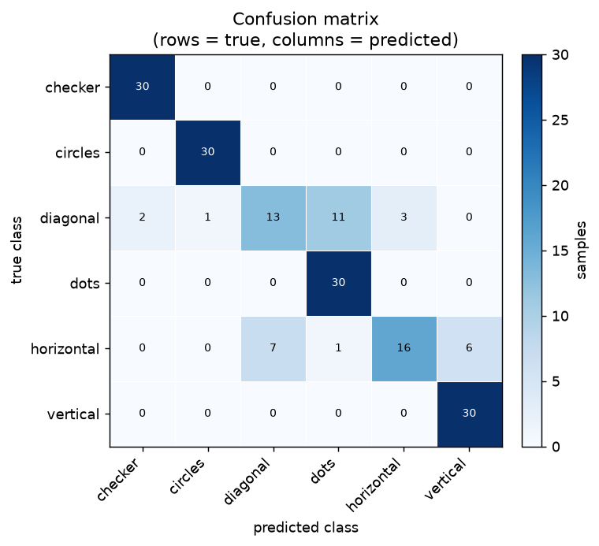

```python
demo_embeddings, demo_embedding_labels = sc.extract_embeddings(demo_model, demo["validation"], DEVICE)
print("extract_embeddings ->", demo_embeddings.shape, demo_embedding_labels.shape,
      "| penultimate layer feeds", f"{type(demo_model.classifier[-1]).__name__}"
      f"(in_features={demo_model.classifier[-1].in_features})")
print("labels returned in loader order:", bool(np.array_equal(demo_embedding_labels, demo_val["labels"])))

demo_figure, demo_axes = sc.plot_confusion_matrix(demo_metrics["confusion_matrix"], CLASS_NAMES)
print("plot_confusion_matrix ->", (type(demo_figure).__name__, type(demo_axes).__name__),
      "| nothing written to disk by the function itself")
plt.close(demo_figure)  # displayed once, as the cell result
demo_figure
```

**Pipeline analysis:** In a few sentences, identify the controls that make model comparisons interpretable and explain how test-set isolation is maintained.

Model comparisons are made interpretable through the deterministic data pipeline in **Task 1**, primarily. Task 1 fixes train/validation/test splits, train-only augmentations, uses deterministic validations/tests transforms, applies ImageNet normalization, and controls training shuffling with a fixed seed. Meanwhile, Task 2 fixes local ImageNet pretrained weights, Task 3 defines a consistent frozen-backbone training/evaluation setup, and Task 4 standardizes the classification metrics used for comparison. Therefore, test-set isolation is maintained by “locking away” the held-out test set so that it is not used during training or model-selection decisions. Instead, it is consulted only after the final model configuration has been chosen.

## 5. Required Experiments

The next cell defines the shared harness used by every experiment: a cumulative long-form metrics recorder, a single `run_training` routine that selects the reported epoch by **validation** accuracy, inference timing, and plotting helpers. Centralizing it is what keeps the comparisons controlled — each experiment varies exactly one factor and everything else (seed, loaders, epoch budget, evaluation protocol) is held fixed.

```python
from PIL import Image
from torch.utils.data import DataLoader, Subset
from torchvision import transforms

METRICS_PATH = PATHS["tables"] / "experiment_metrics.csv"
METRIC_COLUMNS = ["experiment", "method", "condition", "metric", "value", "units"]
METRIC_ROWS, RUNS = [], {}
EPOCHS = 10
DEFAULT_LR = {"frozen": {"adam": 1e-3, "sgd": 1e-2}, "finetune": {"adam": 1e-4, "sgd": 1e-3}}


def record(experiment, method, condition, metric, value, units):
    """Append one long-form record to the cumulative metrics table."""
    METRIC_ROWS.append({"experiment": experiment, "method": method, "condition": condition,
                        "metric": metric, "value": float(value), "units": units})


def write_metrics():
    """Rewrite outputs/tables/experiment_metrics.csv from every record collected so far."""
    frame = pd.DataFrame(METRIC_ROWS, columns=METRIC_COLUMNS)
    frame.to_csv(METRICS_PATH, index=False)
    return frame


def make_optimizer(name, parameters, lr):
    if name == "adam":
        return torch.optim.Adam(parameters, lr=lr)
    if name == "sgd":
        return torch.optim.SGD(parameters, lr=lr, momentum=0.9)
    raise ValueError(f"unsupported optimizer: {name}")


def run_training(name, *, architecture="mobilenet_v3_small", mode="finetune", augmentation="none",
                 optimizer_name="adam", lr=None, epochs=EPOCHS, seed=SEED, loaders=None,
                 num_classes=None, class_names=None, label_smoothing=0.0, cosine=False, store=True):
    """Train one configuration and keep the epoch with the best VALIDATION accuracy.

    Test data is never read here, so every selection decision rests on validation evidence.
    """
    a3_tools.seed_everything(seed)
    if loaders is None:
        loaders = sc.build_dataloaders(a3_tools.dataset_path(), BATCH_SIZE, augmentation, seed, NUM_WORKERS)
    names = list(class_names or getattr(loaders["train"].dataset, "class_names", CLASS_NAMES))
    num_classes = int(num_classes or len(names))
    model = sc.build_model(architecture, num_classes, a3_tools.weight_path(architecture))
    sc.freeze_backbone(model) if mode == "frozen" else sc.unfreeze_all(model)
    counts = a3_tools.parameter_counts(model)
    learning_rate = DEFAULT_LR[mode][optimizer_name] if lr is None else lr
    optimizer = make_optimizer(optimizer_name, [p for p in model.parameters() if p.requires_grad], learning_rate)
    scheduler = torch.optim.lr_scheduler.CosineAnnealingLR(optimizer, T_max=epochs) if cosine else None
    train_criterion = nn.CrossEntropyLoss(label_smoothing=label_smoothing)
    eval_criterion = nn.CrossEntropyLoss()

    history, best_val, best_epoch, best_state = [], -1.0, 0, None
    started = time.time()
    for epoch in range(1, epochs + 1):
        train = sc.train_one_epoch(model, loaders["train"], optimizer, train_criterion, DEVICE)
        validation = sc.evaluate_model(model, loaders["validation"], eval_criterion, DEVICE)
        if scheduler is not None:
            scheduler.step()
        history.append({"epoch": epoch, "train_loss": train["loss"], "train_accuracy": train["accuracy"],
                        "val_loss": validation["loss"], "val_accuracy": validation["accuracy"]})
        if validation["accuracy"] > best_val:
            best_val, best_epoch = validation["accuracy"], epoch
            best_state = {key: value.detach().cpu().clone() for key, value in model.state_dict().items()}
    train_seconds = time.time() - started
    if best_state is not None:
        model.load_state_dict(best_state)

    frame = pd.DataFrame(history)
    run = {"name": name, "architecture": architecture, "mode": mode, "augmentation": augmentation,
           "optimizer": optimizer_name, "lr": learning_rate, "epochs": epochs, "seed": seed,
           "label_smoothing": label_smoothing, "cosine": cosine, "num_classes": num_classes,
           "class_names": names, "history": frame, "model": model, "loaders": loaders,
           "parameter_counts": counts, "best_epoch": best_epoch, "best_val_accuracy": best_val,
           "best_val_loss": float(frame.loc[frame["epoch"] == best_epoch, "val_loss"].iloc[0]),
           "final_train_accuracy": float(frame["train_accuracy"].iloc[-1]),
           "final_train_loss": float(frame["train_loss"].iloc[-1]),
           "final_val_accuracy": float(frame["val_accuracy"].iloc[-1]),
           "train_seconds": train_seconds, "seconds_per_epoch": train_seconds / max(epochs, 1),
           "generalization_gap": float(frame["train_accuracy"].iloc[-1]) - best_val,
           "final_gap": float(frame["train_accuracy"].iloc[-1] - frame["val_accuracy"].iloc[-1])}
    if store:
        RUNS[name] = run
    print(f"[{name}] {architecture} | {mode} | aug={augmentation} | {optimizer_name} lr={learning_rate:g}"
          f" | best val acc {best_val:.4f} @ epoch {best_epoch} | final train acc {run['final_train_accuracy']:.4f}"
          f" | gap {run['generalization_gap']:+.4f} | trainable {counts['trainable']:,} | {train_seconds:.1f}s")
    return run


def record_run(experiment, method, run, *, extra=None):
    """Write the standard block of evidence for one training run."""
    condition = run["name"]
    fields = {"best_val_accuracy": (run["best_val_accuracy"], "fraction"),
              "best_val_loss": (run["best_val_loss"], "cross-entropy"),
              "final_train_accuracy": (run["final_train_accuracy"], "fraction"),
              "final_train_loss": (run["final_train_loss"], "cross-entropy"),
              "generalization_gap": (run["generalization_gap"], "fraction"),
              "selected_epoch": (run["best_epoch"], "epoch"),
              "total_parameters": (run["parameter_counts"]["total"], "count"),
              "trainable_parameters": (run["parameter_counts"]["trainable"], "count"),
              "train_wall_time": (run["train_seconds"], "seconds"),
              "seconds_per_epoch": (run["seconds_per_epoch"], "seconds")}
    fields.update(extra or {})
    for metric, (value, units) in fields.items():
        record(experiment, method, condition, metric, value, units)


def summarize(names):
    """Comparison table for a set of stored runs."""
    return pd.DataFrame([{"run": RUNS[n]["name"], "architecture": RUNS[n]["architecture"], "mode": RUNS[n]["mode"],
                          "augmentation": RUNS[n]["augmentation"], "optimizer": RUNS[n]["optimizer"],
                          "lr": RUNS[n]["lr"], "best_val_acc": RUNS[n]["best_val_accuracy"],
                          "best_val_loss": RUNS[n]["best_val_loss"],
                          "final_train_acc": RUNS[n]["final_train_accuracy"],
                          "gap": RUNS[n]["generalization_gap"],
                          "trainable": RUNS[n]["parameter_counts"]["trainable"],
                          "sec/epoch": RUNS[n]["seconds_per_epoch"]} for n in names])


def pick_best(names):
    """Validation-only selection: highest validation accuracy, lowest validation loss as tie-break."""
    return min(names, key=lambda n: (-RUNS[n]["best_val_accuracy"], RUNS[n]["best_val_loss"]))


def selection_note(names, chosen):
    """State the validation-only basis for a selection, naming the tie-break when it was needed."""
    accuracies = {name: round(RUNS[name]["best_val_accuracy"], 6) for name in names}
    if len(set(accuracies.values())) == 1:
        return (f"validation accuracy saturates at {accuracies[chosen]:.4f} for every condition, so the"
                f" tie-break applies: selected '{chosen}' on the lowest validation loss"
                f" ({RUNS[chosen]['best_val_loss']:.4f})")
    return f"selected '{chosen}' on the highest validation accuracy ({accuracies[chosen]:.4f})"


def inference_milliseconds(model, loader, repeats=5):
    """Mean forward-pass latency per image, measured on pre-loaded batches after a warm-up."""
    model.to(DEVICE).eval()
    batches = [images for images, _ in loader]
    with torch.no_grad():
        for _ in range(2):
            model(batches[0].to(DEVICE))
    if DEVICE.type == "cuda":
        torch.cuda.synchronize()
    started, total = time.perf_counter(), 0
    with torch.no_grad():
        for _ in range(repeats):
            for images in batches:
                model(images.to(DEVICE)); total += images.shape[0]
    if DEVICE.type == "cuda":
        torch.cuda.synchronize()
    return 1000.0 * (time.perf_counter() - started) / total


def test_report(run, *, loaders=None, class_names=None):
    """Evaluate a validation-selected run once on its held-out test split."""
    loaders = loaders or run["loaders"]
    names = list(class_names or run["class_names"])
    evaluation = sc.evaluate_model(run["model"], loaders["test"], nn.CrossEntropyLoss(), DEVICE)
    return evaluation, sc.classification_metrics(evaluation["labels"], evaluation["predictions"], names)


def per_class_table(metrics):
    return pd.DataFrame({"class": metrics["class_names"], "support": metrics["support"],
                         "precision": metrics["precision"], "recall": metrics["recall"],
                         "f1": metrics["f1"], "per_class_accuracy": metrics["per_class_accuracy"]})


def denormalize(tensor):
    """Undo ImageNet normalization so a transformed tensor can be displayed."""
    array = tensor.detach().cpu().numpy().transpose(1, 2, 0)
    return np.clip(array * np.array(sc.IMAGENET_STD) + np.array(sc.IMAGENET_MEAN), 0.0, 1.0)


def draw_confusion(ax, matrix, class_names, *, normalize=True, title="", annotate=None,
                   axis_labels=True):
    """Confusion matrix drawn into an existing axis (for multi-panel figures)."""
    shown = matrix.astype(float)
    if normalize:
        totals = shown.sum(axis=1, keepdims=True)
        shown = np.divide(shown, totals, out=np.zeros_like(shown), where=totals > 0)
    ax.imshow(shown, cmap="Blues", vmin=0, vmax=1 if normalize else max(shown.max(), 1))
    ax.set_xticks(range(len(class_names)), class_names, rotation=45, ha="right", fontsize=8)
    ax.set_yticks(range(len(class_names)), class_names, fontsize=8)
    if axis_labels:
        ax.set_xlabel("predicted"); ax.set_ylabel("true")
    ax.set_title(title, fontsize=10)
    annotate = len(class_names) <= 10 if annotate is None else annotate
    if annotate:
        for row in range(shown.shape[0]):
            for column in range(shown.shape[1]):
                ax.text(column, row, f"{shown[row, column]:.2f}" if normalize else int(matrix[row, column]),
                        ha="center", va="center", fontsize=7,
                        color="white" if shown[row, column] > 0.6 * max(shown.max(), 1e-9) else "black")
    return ax


def external_label_counts(loader):
    """Per-class sample counts for a Hugging Face split, read from the label column only."""
    dataset = loader.dataset
    raw = dataset.split[dataset.label_column]
    if dataset.label_to_index is not None:
        indices = [dataset.label_to_index[value] for value in raw]
    else:
        indices = [int(value) for value in raw]
    return np.bincount(indices, minlength=len(dataset.class_names))


print("harness ready | device", DEVICE, "| batch", BATCH_SIZE, "| workers", NUM_WORKERS,
      "| epochs", EPOCHS, "| image size", sc.IMAGE_SIZE, "| seed", SEED)
```

```
harness ready | device cuda | batch 32 | workers 4 | epochs 10 | image size 224 | seed 5243
```

### Experiment 1 — pretrained architecture comparison (6 points)

Compare MobileNetV3-Small and EfficientNet-B0 under a controlled transfer-learning configuration. Record validation behavior, parameter counts, and inference timing in the cumulative metrics file.

```python
# Controlled: identical seed, loaders, augmentation=none, Adam, frozen backbone, and epoch budget.
for architecture in sc.SUPPORTED_ARCHITECTURES:
    run = run_training(f"exp1_{architecture}", architecture=architecture, mode="frozen",
                       augmentation="none", optimizer_name="adam", epochs=EPOCHS, seed=SEED)
    latency = inference_milliseconds(run["model"], run["loaders"]["test"])
    record_run(1, "frozen transfer (architecture comparison)", run,
               extra={"inference_latency": (latency, "ms/image")})

EXP1_RUNS = [f"exp1_{architecture}" for architecture in sc.SUPPORTED_ARCHITECTURES]
exp1_table = summarize(EXP1_RUNS)
EXP1_CHOICE = pick_best(EXP1_RUNS)
BEST_ARCHITECTURE = RUNS[EXP1_CHOICE]["architecture"]
print(exp1_table.round(4).to_string(index=False))
print("\n" + selection_note(EXP1_RUNS, EXP1_CHOICE), "\nBEST_ARCHITECTURE =", BEST_ARCHITECTURE)
write_metrics().tail(4)
```

```
[exp1_mobilenet_v3_small] mobilenet_v3_small | frozen | aug=none | adam lr=0.001 | best val acc 0.9889 @ epoch 7 | final train acc 0.9986 | gap +0.0097 | trainable 6,150 | 15.6s
```

```
[exp1_efficientnet_b0] efficientnet_b0 | frozen | aug=none | adam lr=0.001 | best val acc 1.0000 @ epoch 2 | final train acc 0.9986 | gap -0.0014 | trainable 7,686 | 24.5s
```

```
                    run       architecture   mode augmentation optimizer    lr  best_val_acc  best_val_loss  final_train_acc     gap  trainable  sec/epoch
exp1_mobilenet_v3_small mobilenet_v3_small frozen         none      adam 0.001        0.9889         0.1987           0.9986  0.0097       6150     1.5627
   exp1_efficientnet_b0    efficientnet_b0 frozen         none      adam 0.001        1.0000         0.1633           0.9986 -0.0014       7686     2.4531

selected 'exp1_efficientnet_b0' on the highest validation accuracy (1.0000)
BEST_ARCHITECTURE = efficientnet_b0
```

|  | experiment | method | condition | metric | value | units |
| --- | --- | --- | --- | --- | --- | --- |
| 18 | 1 | frozen transfer (architecture comparison) | exp1_efficientnet_b0 | trainable_parameters | 7686.000000 | count |
| 19 | 1 | frozen transfer (architecture comparison) | exp1_efficientnet_b0 | train_wall_time | 24.530527 | seconds |
| 20 | 1 | frozen transfer (architecture comparison) | exp1_efficientnet_b0 | seconds_per_epoch | 2.453053 | seconds |
| 21 | 1 | frozen transfer (architecture comparison) | exp1_efficientnet_b0 | inference_latency | 1.818716 | ms/image |

### Experiment 2 — frozen transfer versus full fine-tuning (5 points)

Compare a frozen backbone with full fine-tuning while holding architecture, initialization, data, seed, and evaluation fixed. Record train/validation behavior and computational evidence.

```python
# Controlled: BEST_ARCHITECTURE, same local ImageNet initialization, same loaders/seed/epochs/optimizer.
for mode in ("frozen", "finetune"):
    run = run_training(f"exp2_{mode}", architecture=BEST_ARCHITECTURE, mode=mode, augmentation="none",
                       optimizer_name="adam", epochs=EPOCHS, seed=SEED)
    record_run(2, "frozen transfer vs full fine-tuning", run)

EXP2_RUNS = ["exp2_frozen", "exp2_finetune"]
exp2_table = summarize(EXP2_RUNS)
EXP2_CHOICE = pick_best(EXP2_RUNS)
BEST_MODE = RUNS[EXP2_CHOICE]["mode"]
print(exp2_table.round(4).to_string(index=False))
print(f"\ntrainable-parameter ratio finetune/frozen: "
      f"{RUNS['exp2_finetune']['parameter_counts']['trainable'] / RUNS['exp2_frozen']['parameter_counts']['trainable']:.1f}x"
      f" | cost ratio {RUNS['exp2_finetune']['seconds_per_epoch'] / RUNS['exp2_frozen']['seconds_per_epoch']:.2f}x per epoch")
print(selection_note(EXP2_RUNS, EXP2_CHOICE), "\nBEST_MODE =", BEST_MODE)
write_metrics().tail(4)
```

```
[exp2_frozen] efficientnet_b0 | frozen | aug=none | adam lr=0.001 | best val acc 1.0000 @ epoch 2 | final train acc 0.9986 | gap -0.0014 | trainable 7,686 | 32.7s
```

```
[exp2_finetune] efficientnet_b0 | finetune | aug=none | adam lr=0.0001 | best val acc 1.0000 @ epoch 1 | final train acc 1.0000 | gap +0.0000 | trainable 4,015,234 | 79.0s
          run    architecture     mode augmentation optimizer     lr  best_val_acc  best_val_loss  final_train_acc     gap  trainable  sec/epoch
  exp2_frozen efficientnet_b0   frozen         none      adam 0.0010           1.0         0.1633           0.9986 -0.0014       7686     3.2711
exp2_finetune efficientnet_b0 finetune         none      adam 0.0001           1.0         0.5908           1.0000  0.0000    4015234     7.9038

trainable-parameter ratio finetune/frozen: 522.4x | cost ratio 2.42x per epoch
validation accuracy saturates at 1.0000 for every condition, so the tie-break applies: selected 'exp2_frozen' on the lowest validation loss (0.1633)
BEST_MODE = frozen
```

|  | experiment | method | condition | metric | value | units |
| --- | --- | --- | --- | --- | --- | --- |
| 38 | 2 | frozen transfer vs full fine-tuning | exp2_finetune | total_parameters | 4.015234e+06 | count |
| 39 | 2 | frozen transfer vs full fine-tuning | exp2_finetune | trainable_parameters | 4.015234e+06 | count |
| 40 | 2 | frozen transfer vs full fine-tuning | exp2_finetune | train_wall_time | 7.903834e+01 | seconds |
| 41 | 2 | frozen transfer vs full fine-tuning | exp2_finetune | seconds_per_epoch | 7.903834e+00 | seconds |

### Experiment 3 — augmentation strength (5 points)

Compare no, moderate, and strong training augmentation with deterministic validation transforms. Save `outputs/figures/augmentation_examples.png` and record controlled validation evidence.

```python
# --- augmentation_examples.png: one original row plus one row per augmentation level -------------
archive = np.load(a3_tools.dataset_path())
examples = [int(np.flatnonzero(archive["train_labels"] == index)[0]) for index in range(NUM_CLASSES)]
rows = [("original", None)] + [(level, sc.training_transform(level)) for level in sc.AUGMENTATION_LEVELS]
a3_tools.seed_everything(SEED)
figure, axes = plt.subplots(len(rows), len(examples), figsize=(2.0 * len(examples), 2.15 * len(rows)), dpi=130)
for row, (label, transform) in enumerate(rows):
    for column, index in enumerate(examples):
        image = Image.fromarray(archive["train_images"][index])
        shown = np.asarray(image) / 255.0 if transform is None else denormalize(transform(image))
        axis = axes[row, column]
        axis.imshow(shown); axis.set_xticks([]); axis.set_yticks([])
        if row == 0:
            axis.set_title(CLASS_NAMES[int(archive["train_labels"][index])], fontsize=10)
        if column == 0:
            axis.set_ylabel(label, fontsize=11)
figure.suptitle("Training augmentation levels (validation and test transforms remain deterministic)", y=1.0)
figure.tight_layout()
figure.savefig(PATHS["figures"] / "augmentation_examples.png", bbox_inches="tight")
plt.close(figure)

# --- controlled comparison: only the training augmentation changes ------------------------------
for level in sc.AUGMENTATION_LEVELS:
    run = run_training(f"exp3_{level}", architecture=BEST_ARCHITECTURE, mode=BEST_MODE, augmentation=level,
                       optimizer_name="adam", epochs=EPOCHS, seed=SEED)
    record_run(3, "training augmentation strength", run)

EXP3_RUNS = [f"exp3_{level}" for level in sc.AUGMENTATION_LEVELS]
exp3_table = summarize(EXP3_RUNS)
EXP3_CHOICE = pick_best(EXP3_RUNS)
BEST_AUGMENTATION = RUNS[EXP3_CHOICE]["augmentation"]
print(exp3_table.round(4).to_string(index=False))
print("\nsaved", (PATHS["figures"] / "augmentation_examples.png").name)
print(selection_note(EXP3_RUNS, EXP3_CHOICE), "\nBEST_AUGMENTATION =", BEST_AUGMENTATION)
write_metrics().tail(4)
```

```
[exp3_none] efficientnet_b0 | frozen | aug=none | adam lr=0.001 | best val acc 1.0000 @ epoch 2 | final train acc 0.9986 | gap -0.0014 | trainable 7,686 | 30.5s
```

```
[exp3_moderate] efficientnet_b0 | frozen | aug=moderate | adam lr=0.001 | best val acc 1.0000 @ epoch 2 | final train acc 0.9972 | gap -0.0028 | trainable 7,686 | 30.5s
```

```
[exp3_strong] efficientnet_b0 | frozen | aug=strong | adam lr=0.001 | best val acc 1.0000 @ epoch 5 | final train acc 0.9792 | gap -0.0208 | trainable 7,686 | 32.5s
          run    architecture   mode augmentation optimizer    lr  best_val_acc  best_val_loss  final_train_acc     gap  trainable  sec/epoch
    exp3_none efficientnet_b0 frozen         none      adam 0.001           1.0         0.1633           0.9986 -0.0014       7686     3.0532
exp3_moderate efficientnet_b0 frozen     moderate      adam 0.001           1.0         0.1969           0.9972 -0.0028       7686     3.0480
  exp3_strong efficientnet_b0 frozen       strong      adam 0.001           1.0         0.3204           0.9792 -0.0208       7686     3.2521

saved augmentation_examples.png
validation accuracy saturates at 1.0000 for every condition, so the tie-break applies: selected 'exp3_none' on the lowest validation loss (0.1633)
BEST_AUGMENTATION = none
```

|  | experiment | method | condition | metric | value | units |
| --- | --- | --- | --- | --- | --- | --- |
| 68 | 3 | training augmentation strength | exp3_strong | total_parameters | 4.015234e+06 | count |
| 69 | 3 | training augmentation strength | exp3_strong | trainable_parameters | 7.686000e+03 | count |
| 70 | 3 | training augmentation strength | exp3_strong | train_wall_time | 3.252056e+01 | seconds |
| 71 | 3 | training augmentation strength | exp3_strong | seconds_per_epoch | 3.252056e+00 | seconds |

### Experiment 4 — optimization (5 points)

Compare SGD and Adam under the same model, initialization, data budget, and evaluation protocol. Save one consolidated `outputs/figures/training_curves.png` covering the required training comparisons.

```
[exp4_sgd] efficientnet_b0 | frozen | aug=none | sgd lr=0.01 | best val acc 1.0000 @ epoch 2 | final train acc 0.9986 | gap -0.0014 | trainable 7,686 | 30.3s
```

```
[exp4_adam] efficientnet_b0 | frozen | aug=none | adam lr=0.001 | best val acc 1.0000 @ epoch 2 | final train acc 0.9986 | gap -0.0014 | trainable 7,686 | 30.9s
      run    architecture   mode augmentation optimizer    lr  best_val_acc  best_val_loss  final_train_acc     gap  trainable  sec/epoch
 exp4_sgd efficientnet_b0 frozen         none       sgd 0.010           1.0         0.0382           0.9986 -0.0014       7686     3.0259
exp4_adam efficientnet_b0 frozen         none      adam 0.001           1.0         0.1633           0.9986 -0.0014       7686     3.0927

validation accuracy saturates at 1.0000 for every condition, so the tie-break applies: selected 'exp4_sgd' on the lowest validation loss (0.0382)
BEST_OPTIMIZER = sgd
```

```
saved training_curves.png
```

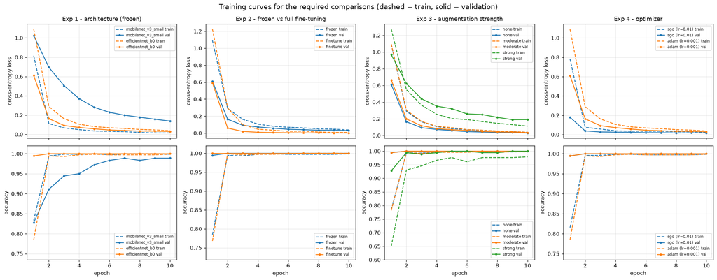

```python
# Controlled: same model, initialization, loaders, augmentation, seed, and epoch budget.
for optimizer_name in ("sgd", "adam"):
    run = run_training(f"exp4_{optimizer_name}", architecture=BEST_ARCHITECTURE, mode=BEST_MODE,
                       augmentation=BEST_AUGMENTATION, optimizer_name=optimizer_name,
                       epochs=EPOCHS, seed=SEED)
    record_run(4, "optimizer comparison", run, extra={"learning_rate": (run["lr"], "lr")})

EXP4_RUNS = ["exp4_sgd", "exp4_adam"]
exp4_table = summarize(EXP4_RUNS)
EXP4_CHOICE = pick_best(EXP4_RUNS)
BEST_OPTIMIZER = RUNS[EXP4_CHOICE]["optimizer"]
print(exp4_table.round(4).to_string(index=False))
print("\n" + selection_note(EXP4_RUNS, EXP4_CHOICE), "\nBEST_OPTIMIZER =", BEST_OPTIMIZER)

# --- training_curves.png: one consolidated figure for Experiments 1-4 --------------------------
panels = [("Exp 1 - architecture (frozen)", EXP1_RUNS, lambda r: r["architecture"]),
          ("Exp 2 - frozen vs full fine-tuning", EXP2_RUNS, lambda r: r["mode"]),
          ("Exp 3 - augmentation strength", EXP3_RUNS, lambda r: r["augmentation"]),
          ("Exp 4 - optimizer", EXP4_RUNS, lambda r: f"{r['optimizer']} (lr={r['lr']:g})")]
figure, axes = plt.subplots(2, 4, figsize=(19, 7.5), dpi=120, sharex=True)
colors = plt.get_cmap("tab10").colors
for column, (title, names, label_of) in enumerate(panels):
    for index, name in enumerate(names):
        history = RUNS[name]["history"]; label = label_of(RUNS[name]); color = colors[index]
        axes[0, column].plot(history["epoch"], history["train_loss"], "--", color=color, label=f"{label} train")
        axes[0, column].plot(history["epoch"], history["val_loss"], "-o", ms=3, color=color, label=f"{label} val")
        axes[1, column].plot(history["epoch"], history["train_accuracy"], "--", color=color, label=f"{label} train")
        axes[1, column].plot(history["epoch"], history["val_accuracy"], "-o", ms=3, color=color, label=f"{label} val")
    axes[0, column].set_title(title, fontsize=11)
    axes[0, column].set_ylabel("cross-entropy loss"); axes[1, column].set_ylabel("accuracy")
    accuracy_floor = min(min(RUNS[n]["history"][["train_accuracy", "val_accuracy"]].min()) for n in names)
    axes[1, column].set_xlabel("epoch")
    axes[1, column].set_ylim(max(0.0, accuracy_floor - 0.05), 1.02)
    for row in (0, 1):
        axes[row, column].grid(alpha=0.3)
        axes[row, column].legend(fontsize=7, loc="best")
figure.suptitle("Training curves for the required comparisons (dashed = train, solid = validation)", fontsize=13)
figure.tight_layout()
figure.savefig(PATHS["figures"] / "training_curves.png", bbox_inches="tight")
print("saved", (PATHS["figures"] / "training_curves.png").name)
write_metrics().tail(4)
plt.close(figure)  # displayed once, as the cell result
figure
```

### Experiments 5–6 — embeddings and classifier evaluation (7 points)

Select the final configuration using validation evidence. Extract test embeddings and save a labeled PCA or t-SNE projection as `embedding_visualization.png`. Save `confusion_matrix.png`; report accuracy and per-class accuracy, precision, recall, and F1. For this single-label task, per-class accuracy equals recall; report both values for a complete class-wise table. Write one row per test sample to `predictions.csv` using the README schema.

```
SELECTED_CONFIG {'architecture': 'efficientnet_b0', 'mode': 'frozen', 'augmentation': 'none', 'optimizer_name': 'sgd'}
```

```
[final] efficientnet_b0 | frozen | aug=none | sgd lr=0.01 | best val acc 1.0000 @ epoch 2 | final train acc 0.9986 | gap -0.0014 | trainable 7,686 | 30.2s
```

```
test accuracy 1.0000 | macro F1 1.0000 | test loss 0.0322
     class  support  precision  recall  f1  per_class_accuracy
   checker       30        1.0     1.0 1.0                 1.0
   circles       30        1.0     1.0 1.0                 1.0
  diagonal       30        1.0     1.0 1.0                 1.0
      dots       30        1.0     1.0 1.0                 1.0
horizontal       30        1.0     1.0 1.0                 1.0
  vertical       30        1.0     1.0 1.0                 1.0
```

```
wrote predictions.csv (180, 5) | saved confusion_matrix.png, embedding_visualization.png
sample_id split true_label predicted_label  confidence
test_0000  test   diagonal        diagonal    0.702334
test_0001  test    checker         checker    0.837777
test_0002  test   diagonal        diagonal    0.936469
```

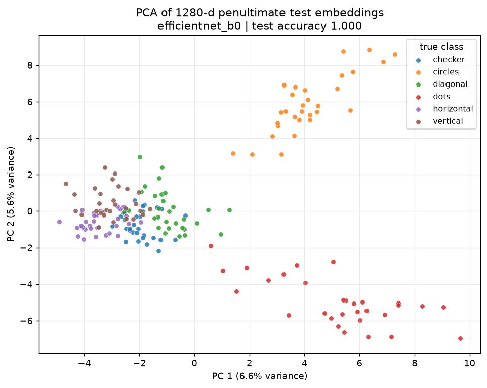

```python
# --- final configuration: the winning level of every factor, each chosen on validation only ----
SELECTED_CONFIG = {"architecture": BEST_ARCHITECTURE, "mode": BEST_MODE,
                   "augmentation": BEST_AUGMENTATION, "optimizer_name": BEST_OPTIMIZER}
SELECTED_BY = ("factor-wise winners of Experiments 1-4, each chosen on validation accuracy with "
               "validation loss as tie-break; the reported epoch is the best validation epoch. "
               "The test split was not consulted for any selection decision.")
print("SELECTED_CONFIG", SELECTED_CONFIG)
FINAL_RUN = run_training("final", epochs=EPOCHS, seed=SEED, **SELECTED_CONFIG)
record_run(5, "validation-selected final model", FINAL_RUN,
           extra={"inference_latency": (inference_milliseconds(FINAL_RUN["model"], FINAL_RUN["loaders"]["test"]),
                                        "ms/image")})

# --- Experiment 6: one held-out test evaluation of the selected model ---------------------------
test_evaluation, test_metrics = test_report(FINAL_RUN)
print(f"\ntest accuracy {test_metrics['accuracy']:.4f} | macro F1 {test_metrics['macro_f1']:.4f} "
      f"| test loss {test_evaluation['loss']:.4f}")
print(per_class_table(test_metrics).round(4).to_string(index=False))
record(6, "held-out test evaluation", "final", "test_accuracy", test_metrics["accuracy"], "fraction")
record(6, "held-out test evaluation", "final", "test_loss", test_evaluation["loss"], "cross-entropy")
record(6, "held-out test evaluation", "final", "test_macro_f1", test_metrics["macro_f1"], "fraction")
for index, class_name in enumerate(CLASS_NAMES):
    for metric in ("precision", "recall", "f1", "per_class_accuracy"):
        record(6, "held-out test evaluation", class_name, f"test_{metric}", test_metrics[metric][index], "fraction")

# --- confusion_matrix.png ----------------------------------------------------------------------
confusion_figure, _ = sc.plot_confusion_matrix(test_metrics["confusion_matrix"], CLASS_NAMES)
confusion_figure.savefig(PATHS["figures"] / "confusion_matrix.png", bbox_inches="tight")

# --- embedding_visualization.png: PCA of penultimate test embeddings ---------------------------
embeddings, embedding_labels = sc.extract_embeddings(FINAL_RUN["model"], FINAL_RUN["loaders"]["test"], DEVICE)
projection = PCA(n_components=2, random_state=SEED)
points = projection.fit_transform(embeddings)
variance = projection.explained_variance_ratio_
embedding_figure, embedding_axis = plt.subplots(figsize=(7.5, 6.0), dpi=130)
for index, class_name in enumerate(CLASS_NAMES):
    mask = embedding_labels == index
    embedding_axis.scatter(points[mask, 0], points[mask, 1], s=28, alpha=0.85,
                           color=plt.get_cmap("tab10").colors[index], label=class_name,
                           edgecolors="white", linewidths=0.4)
embedding_axis.set_xlabel(f"PC 1 ({variance[0]:.1%} variance)")
embedding_axis.set_ylabel(f"PC 2 ({variance[1]:.1%} variance)")
embedding_axis.set_title(f"PCA of {embeddings.shape[1]}-d penultimate test embeddings\n"
                         f"{SELECTED_CONFIG['architecture']} | test accuracy {test_metrics['accuracy']:.3f}")
embedding_axis.legend(title="true class", fontsize=9, loc="best"); embedding_axis.grid(alpha=0.25)
embedding_figure.tight_layout()
embedding_figure.savefig(PATHS["figures"] / "embedding_visualization.png", bbox_inches="tight")
record(5, "penultimate embeddings", "test split", "embedding_dimension", embeddings.shape[1], "features")
record(5, "penultimate embeddings", "test split", "pca_variance_first_two", float(variance[:2].sum()), "fraction")

# --- predictions.csv: one row per test sample --------------------------------------------------
predictions_frame = pd.DataFrame({
    "sample_id": [f"test_{index:04d}" for index in range(len(test_evaluation["labels"]))],
    "split": "test",
    "true_label": [CLASS_NAMES[index] for index in test_evaluation["labels"]],
    "predicted_label": [CLASS_NAMES[index] for index in test_evaluation["predictions"]],
    "confidence": test_evaluation["probabilities"].max(axis=1).round(6)})
predictions_frame.to_csv(PATHS["tables"] / "predictions.csv", index=False)
print("\nwrote", (PATHS["tables"] / "predictions.csv").name, predictions_frame.shape,
      "| saved confusion_matrix.png, embedding_visualization.png")
print(predictions_frame.head(3).to_string(index=False))
write_metrics().tail(3)
plt.close(confusion_figure)
plt.close(embedding_figure)  # displayed once, as the cell result
embedding_figure
```

### Experiment 7 — robustness (3 points)

Apply one controlled degradation—Gaussian noise, blur, brightness, JPEG compression, or occlusion—to the test inputs without retraining. Compare original and degraded accuracy and save `outputs/figures/robustness_results.png`. Then save the selected model's final artifacts: its state dictionary as `outputs/models/trained_model.pt` (see `a3_tools.save_state_dict`) and `outputs/tables/model_metadata.json` using the README schema.

```
 sigma  accuracy   loss  macro_f1  mean_confidence
  0.00    1.0000 0.0322    1.0000           0.9702
  0.02    1.0000 0.0594    1.0000           0.9452
  0.05    0.9833 0.2740    0.9832           0.7890
  0.10    0.6111 1.1326    0.5893           0.4742
  0.20    0.1056 1.9242    0.0905           0.2627

original 1.0000 -> degraded (sigma=0.20) 0.1056 | drop 0.8944
```

```
saved trained_model.pt (16.4 MB, state dictionary only, no optimizer state) and model_metadata.json
```

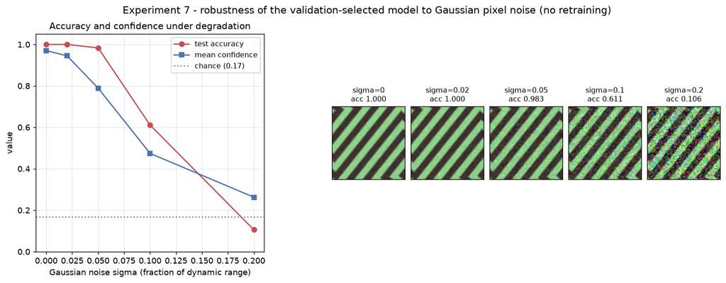

```python
# --- controlled degradation: additive Gaussian pixel noise, no retraining ----------------------
NOISE_SIGMAS = [0.0, 0.02, 0.05, 0.10, 0.20]
noise_rng = np.random.default_rng(SEED)
clean_test = archive["test_images"].astype(np.float32)
test_labels = archive["test_labels"]


def noisy_test_loader(sigma):
    """Test loader with Gaussian noise applied in pixel space before the deterministic transform."""
    noisy = np.clip(clean_test + noise_rng.normal(0.0, sigma * 255.0, clean_test.shape), 0, 255).astype(np.uint8)
    dataset = sc.ArrayImageDataset(noisy, test_labels, sc.evaluation_transform(), CLASS_NAMES)
    return DataLoader(dataset, batch_size=BATCH_SIZE, shuffle=False, num_workers=NUM_WORKERS), noisy


robustness, degraded_examples = [], {}
for sigma in NOISE_SIGMAS:
    loader, noisy_images = noisy_test_loader(sigma)
    evaluation = sc.evaluate_model(FINAL_RUN["model"], loader, nn.CrossEntropyLoss(), DEVICE)
    metrics = sc.classification_metrics(evaluation["labels"], evaluation["predictions"], CLASS_NAMES)
    degraded_examples[sigma] = noisy_images[0]
    robustness.append({"sigma": sigma, "accuracy": metrics["accuracy"], "loss": evaluation["loss"],
                       "macro_f1": metrics["macro_f1"],
                       "mean_confidence": float(evaluation["probabilities"].max(axis=1).mean())})
    condition = f"gaussian_noise_sigma={sigma:g}"
    record(7, "robustness to Gaussian pixel noise", condition, "test_accuracy", metrics["accuracy"], "fraction")
    record(7, "robustness to Gaussian pixel noise", condition, "test_loss", evaluation["loss"], "cross-entropy")
    record(7, "robustness to Gaussian pixel noise", condition, "test_macro_f1", metrics["macro_f1"], "fraction")
    record(7, "robustness to Gaussian pixel noise", condition, "mean_confidence",
           robustness[-1]["mean_confidence"], "probability")

robustness_table = pd.DataFrame(robustness)
clean_accuracy = robustness_table["accuracy"].iloc[0]
worst_accuracy = robustness_table["accuracy"].iloc[-1]
record(7, "robustness to Gaussian pixel noise", "original vs sigma=0.20", "accuracy_drop",
       clean_accuracy - worst_accuracy, "fraction")
print(robustness_table.round(4).to_string(index=False))
print(f"\noriginal {clean_accuracy:.4f} -> degraded (sigma=0.20) {worst_accuracy:.4f} "
      f"| drop {clean_accuracy - worst_accuracy:.4f}")

figure = plt.figure(figsize=(15, 4.8), dpi=130)
grid = figure.add_gridspec(1, 2, width_ratios=[1.0, 1.7], wspace=0.22)
axis = figure.add_subplot(grid[0, 0])
axis.plot(robustness_table["sigma"], robustness_table["accuracy"], "-o", color="#c44e52", label="test accuracy")
axis.plot(robustness_table["sigma"], robustness_table["mean_confidence"], "-s", color="#4c72b0",
          label="mean confidence")
axis.axhline(1.0 / NUM_CLASSES, ls=":", color="gray", label=f"chance ({1 / NUM_CLASSES:.2f})")
axis.set_xlabel("Gaussian noise sigma (fraction of dynamic range)"); axis.set_ylabel("value")
axis.set_ylim(0.0, 1.05); axis.grid(alpha=0.3); axis.legend(fontsize=9)
axis.set_title("Accuracy and confidence under degradation", fontsize=11)
inner = grid[0, 1].subgridspec(1, len(NOISE_SIGMAS), wspace=0.08)
for column, sigma in enumerate(NOISE_SIGMAS):
    tile = figure.add_subplot(inner[0, column])
    tile.imshow(degraded_examples[sigma]); tile.set_xticks([]); tile.set_yticks([])
    tile.set_title(f"sigma={sigma:g}\nacc {robustness_table['accuracy'].iloc[column]:.3f}", fontsize=9)
figure.suptitle("Experiment 7 - robustness of the validation-selected model to Gaussian pixel noise "
                "(no retraining)", fontsize=12)
figure.savefig(PATHS["figures"] / "robustness_results.png", bbox_inches="tight")

# --- final artifacts for the submitted model ---------------------------------------------------
checkpoint = a3_tools.save_state_dict(PATHS["models"] / "trained_model.pt", FINAL_RUN["model"])
size_mb = checkpoint.stat().st_size / 1e6
final_counts = a3_tools.parameter_counts(FINAL_RUN["model"])
model_metadata = {"architecture": FINAL_RUN["architecture"], "num_classes": NUM_CLASSES,
                  "class_names": CLASS_NAMES, "checkpoint": "outputs/models/trained_model.pt",
                  "parameter_counts": {"total": int(final_counts["total"]),
                                       "trainable": int(final_counts["trainable"])},
                  "seed": SEED, "selected_by": SELECTED_BY,
                  "training": {"mode": FINAL_RUN["mode"], "augmentation": FINAL_RUN["augmentation"],
                               "optimizer": FINAL_RUN["optimizer"], "learning_rate": FINAL_RUN["lr"],
                               "epochs": FINAL_RUN["epochs"], "selected_epoch": FINAL_RUN["best_epoch"],
                               "batch_size": BATCH_SIZE, "image_size": sc.IMAGE_SIZE},
                  "validation_accuracy": FINAL_RUN["best_val_accuracy"],
                  "test_accuracy": test_metrics["accuracy"]}
(PATHS["tables"] / "model_metadata.json").write_text(json.dumps(model_metadata, indent=2) + "\n")
print(f"\nsaved {checkpoint.name} ({size_mb:.1f} MB, state dictionary only, no optimizer state) "
      f"and model_metadata.json")
assert size_mb <= 25.0, f"checkpoint exceeds the 25 MB limit ({size_mb:.1f} MB)"
write_metrics().tail(3)
plt.close(figure)  # displayed once, as the cell result
figure
```

### Experiment 8 — real-world transfer: class imbalance (Skin Cancer / HAM10000, 8 points)

Implement `build_external_dataloaders` and use it to load `marmal88/skin_cancer` (Hugging Face Hub; label column `dx`, 7 real diagnostic classes stored as strings) with the `datasets` library — the one required exception to the fully offline pipeline, and reachable only through this one call. Load it inside `build_external_dataloaders` as follows:

```
raw = datasets.load_dataset(hf_dataset_name)
if hf_dataset_name == "marmal88/skin_cancer":
    raw = a3_tools.resplit_by_lesion(raw)
```

`resplit_by_lesion` returns `train`/`validation`/`test` splits (7153/1431/1431 images) that keep every image of a lesion in one split, using a fixed seed shared by the whole class; the rest of your function is unchanged. Fine-tune the architecture you selected in Experiments 5–6 using the same training/evaluation functions already implemented. Save one figure `outputs/figures/skin_cancer_class_balance.png` showing per-class training-sample counts next to per-class test F1 on one figure, so the link between class imbalance and per-class performance is visible without narration. Append rows to `experiment_metrics.csv`. This is a controlled classroom exercise only, not a diagnostic tool — do not present its output as medical guidance.

```
lesion-level splits {'train': 7153, 'validation': 1431, 'test': 1431}
diagnostic classes  ['actinic_keratoses', 'basal_cell_carcinoma', 'benign_keratosis-like_lesions', 'dermatofibroma', 'melanocytic_Nevi', 'melanoma', 'vascular_lesions']
```

```
training images per class {'actinic_keratoses': 233, 'basal_cell_carcinoma': 368, 'benign_keratosis-like_lesions': 785, 'dermatofibroma': 81, 'melanocytic_Nevi': 4790, 'melanoma': 795, 'vascular_lesions': 101}
imbalance ratio (largest/smallest) 59.1x
```

```
[exp8_skin_cancer] efficientnet_b0 | finetune | aug=none | sgd lr=0.001 | best val acc 0.7764 @ epoch 3 | final train acc 0.7860 | gap +0.0096 | trainable 4,016,515 | 229.9s
```

```
test accuracy 0.7952 | macro F1 0.4792 | majority-class share of training data 0.670
                        class  support  precision  recall     f1  per_class_accuracy  train_images
            actinic_keratoses       47     0.6296  0.3617 0.4595              0.3617           233
         basal_cell_carcinoma       73     0.4845  0.6438 0.5529              0.6438           368
benign_keratosis-like_lesions      157     0.5915  0.5350 0.5619              0.5350           785
               dermatofibroma       17     0.0000  0.0000 0.0000              0.0000            81
             melanocytic_Nevi      957     0.8695  0.9676 0.9159              0.9676          4790
                     melanoma      159     0.6374  0.3648 0.4640              0.3648           795
             vascular_lesions       21     0.6667  0.2857 0.4000              0.2857           101
```

```
saved skin_cancer_class_balance.png | classroom exercise only - not medical guidance
```

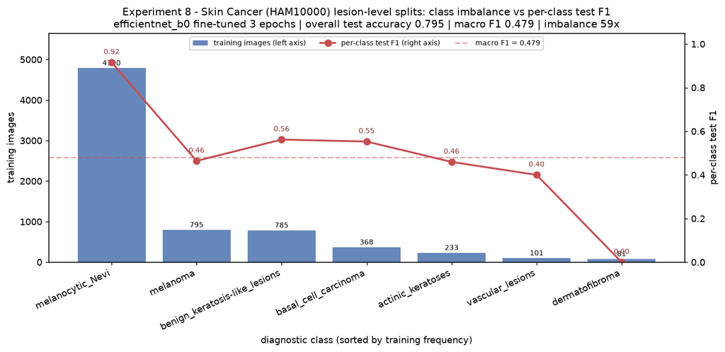

```python
# The one approved network call: build_external_dataloaders downloads marmal88/skin_cancer and
# applies a3_tools.resplit_by_lesion so every image of a lesion stays in a single split.
EXTERNAL_EPOCHS, EXTERNAL_WORKERS = 3, 6
skin_loaders = sc.build_external_dataloaders("marmal88/skin_cancer", "dx", BATCH_SIZE,
                                             BEST_AUGMENTATION, SEED, EXTERNAL_WORKERS)
SKIN_CLASSES = skin_loaders["train"].dataset.class_names
print("lesion-level splits", {name: len(loader.dataset) for name, loader in skin_loaders.items()})
print("diagnostic classes ", SKIN_CLASSES)

skin_train_counts = external_label_counts(skin_loaders["train"])
imbalance_ratio = float(skin_train_counts.max() / max(skin_train_counts.min(), 1))
print("training images per class", dict(zip(SKIN_CLASSES, skin_train_counts.tolist())),
      f"\nimbalance ratio (largest/smallest) {imbalance_ratio:.1f}x")

SKIN_RUN = run_training("exp8_skin_cancer", architecture=BEST_ARCHITECTURE, mode="finetune",
                        augmentation=BEST_AUGMENTATION, optimizer_name=BEST_OPTIMIZER,
                        epochs=EXTERNAL_EPOCHS, seed=SEED, loaders=skin_loaders,
                        num_classes=len(SKIN_CLASSES), class_names=SKIN_CLASSES)
skin_evaluation, skin_metrics = test_report(SKIN_RUN)
majority_share = float(skin_train_counts.max() / skin_train_counts.sum())
print(f"\ntest accuracy {skin_metrics['accuracy']:.4f} | macro F1 {skin_metrics['macro_f1']:.4f} "
      f"| majority-class share of training data {majority_share:.3f}")
skin_table = per_class_table(skin_metrics).assign(train_images=skin_train_counts)
print(skin_table.round(4).to_string(index=False))

record_run(8, "real-world transfer: class imbalance (Skin Cancer)", SKIN_RUN)
record(8, "real-world transfer: class imbalance (Skin Cancer)", "test split", "test_accuracy",
       skin_metrics["accuracy"], "fraction")
record(8, "real-world transfer: class imbalance (Skin Cancer)", "test split", "test_macro_f1",
       skin_metrics["macro_f1"], "fraction")
record(8, "real-world transfer: class imbalance (Skin Cancer)", "test split", "test_loss",
       skin_evaluation["loss"], "cross-entropy")
record(8, "real-world transfer: class imbalance (Skin Cancer)", "train split", "class_imbalance_ratio",
       imbalance_ratio, "ratio")
record(8, "real-world transfer: class imbalance (Skin Cancer)", "train split", "majority_class_share",
       majority_share, "fraction")
for index, class_name in enumerate(SKIN_CLASSES):
    record(8, "real-world transfer: class imbalance (Skin Cancer)", class_name, "train_images",
           int(skin_train_counts[index]), "count")
    record(8, "real-world transfer: class imbalance (Skin Cancer)", class_name, "test_f1",
           skin_metrics["f1"][index], "fraction")
    record(8, "real-world transfer: class imbalance (Skin Cancer)", class_name, "test_per_class_accuracy",
           skin_metrics["per_class_accuracy"][index], "fraction")

# --- skin_cancer_class_balance.png: training counts next to per-class test F1 -------------------
order = np.argsort(-skin_train_counts)
positions = np.arange(len(SKIN_CLASSES))
figure, axis = plt.subplots(figsize=(11, 5.4), dpi=130)
bars = axis.bar(positions, skin_train_counts[order], color="#4c72b0", alpha=0.85,
                label="training images (left axis)")
axis.bar_label(bars, fmt="%d", fontsize=8, padding=1)
axis.set_xticks(positions, [SKIN_CLASSES[index] for index in order], rotation=25, ha="right")
axis.set_ylabel("training images"); axis.set_ylim(0, skin_train_counts.max() * 1.18)
axis.set_xlabel("diagnostic class (sorted by training frequency)")
twin = axis.twinx()
twin.plot(positions, skin_metrics["f1"][order], "-o", color="#c44e52", lw=2, ms=7,
          label="per-class test F1 (right axis)")
for position, value in zip(positions, skin_metrics["f1"][order]):
    twin.annotate(f"{value:.2f}", (position, value), textcoords="offset points", xytext=(0, 9),
                  ha="center", fontsize=8, color="#8c2f35")
twin.axhline(skin_metrics["macro_f1"], ls="--", color="#c44e52", alpha=0.5,
             label=f"macro F1 = {skin_metrics['macro_f1']:.3f}")
twin.set_ylabel("per-class test F1"); twin.set_ylim(0.0, 1.05)
handles = axis.get_legend_handles_labels()[0] + twin.get_legend_handles_labels()[0]
labels = axis.get_legend_handles_labels()[1] + twin.get_legend_handles_labels()[1]
twin.legend(handles, labels, loc="upper center", fontsize=8, ncols=3, framealpha=0.92)
axis.set_title(f"Experiment 8 - Skin Cancer (HAM10000) lesion-level splits: class imbalance vs per-class test F1\n"
               f"{BEST_ARCHITECTURE} fine-tuned {EXTERNAL_EPOCHS} epochs | overall test accuracy "
               f"{skin_metrics['accuracy']:.3f} | macro F1 {skin_metrics['macro_f1']:.3f} | "
               f"imbalance {imbalance_ratio:.0f}x", fontsize=11)
figure.tight_layout()
figure.savefig(PATHS["figures"] / "skin_cancer_class_balance.png", bbox_inches="tight")
print("\nsaved", (PATHS["figures"] / "skin_cancer_class_balance.png").name,
      "| classroom exercise only - not medical guidance")
write_metrics().tail(3)
plt.close(figure)  # displayed once, as the cell result
figure
```

### Experiment 9 — real-world transfer: domain shift (EuroSAT, 7 points)

Use `build_external_dataloaders` to load `timm/eurosat-rgb` (Hugging Face Hub; label column `label`, 10 land-use classes, real satellite imagery) and fine-tune your selected architecture the same way. This tests whether ImageNet-pretrained features — learned from everyday photos of objects and scenes — still transfer to a visually unrelated domain (overhead satellite tiles). Save one figure `outputs/figures/eurosat_transfer_results.png` combining a few example tiles with the resulting confusion matrix or per-class accuracy, so the domain-shift effect is visible in one image. Append rows to `experiment_metrics.csv`.

```
published splits    {'train': 16200, 'validation': 5400, 'test': 5400}
land-use classes    ['AnnualCrop', 'Forest', 'HerbaceousVegetation', 'Highway', 'Industrial', 'Pasture', 'PermanentCrop', 'Residential', 'River', 'SeaLake']
training images per class {'AnnualCrop': 1791, 'Forest': 1787, 'HerbaceousVegetation': 1799, 'Highway': 1505, 'Industrial': 1492, 'Pasture': 1195, 'PermanentCrop': 1481, 'Residential': 1863, 'River': 1460, 'SeaLake': 1827}
```

```
[exp9_eurosat] efficientnet_b0 | finetune | aug=none | sgd lr=0.001 | best val acc 0.9635 @ epoch 3 | final train acc 0.9552 | gap -0.0083 | trainable 4,020,358 | 504.5s
```

```
test accuracy 0.9674 | macro F1 0.9673 | chance 0.100
               class  support  precision  recall     f1  per_class_accuracy
          AnnualCrop      596     0.9381  0.9664 0.9521              0.9664
              Forest      608     0.9966  0.9589 0.9774              0.9589
HerbaceousVegetation      573     0.9106  0.9773 0.9428              0.9773
             Highway      496     0.9739  0.9798 0.9769              0.9798
          Industrial      501     0.9959  0.9780 0.9869              0.9780
             Pasture      396     0.9762  0.9318 0.9535              0.9318
       PermanentCrop      538     0.9722  0.9108 0.9405              0.9108
         Residential      554     0.9892  0.9964 0.9928              0.9964
               River      529     0.9753  0.9716 0.9735              0.9716
             SeaLake      609     0.9618  0.9918 0.9766              0.9918
```

```
[exp9_eurosat_frozen] efficientnet_b0 | frozen | aug=none | sgd lr=0.01 | best val acc 0.9202 @ epoch 3 | final train acc 0.8912 | gap -0.0290 | trainable 12,810 | 180.2s
```

```
frozen linear probe test accuracy 0.9224 | fine-tuned 0.9674 | adaptation gain +0.0450
```

```
saved eurosat_transfer_results.png
```

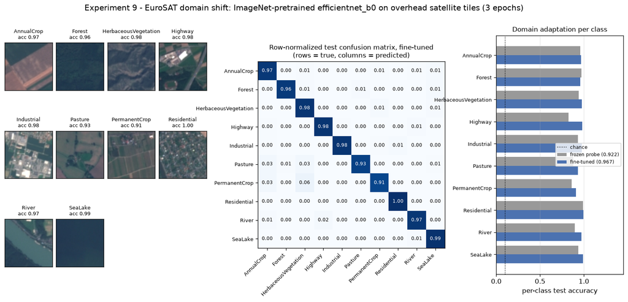

```python
eurosat_loaders = sc.build_external_dataloaders("timm/eurosat-rgb", "label", BATCH_SIZE,
                                                BEST_AUGMENTATION, SEED, EXTERNAL_WORKERS)
EUROSAT_CLASSES = eurosat_loaders["train"].dataset.class_names
print("published splits   ", {name: len(loader.dataset) for name, loader in eurosat_loaders.items()})
print("land-use classes   ", EUROSAT_CLASSES)
eurosat_train_counts = external_label_counts(eurosat_loaders["train"])
print("training images per class", dict(zip(EUROSAT_CLASSES, eurosat_train_counts.tolist())))

EUROSAT_RUN = run_training("exp9_eurosat", architecture=BEST_ARCHITECTURE, mode="finetune",
                           augmentation=BEST_AUGMENTATION, optimizer_name=BEST_OPTIMIZER,
                           epochs=EXTERNAL_EPOCHS, seed=SEED, loaders=eurosat_loaders,
                           num_classes=len(EUROSAT_CLASSES), class_names=EUROSAT_CLASSES)
eurosat_evaluation, eurosat_metrics = test_report(EUROSAT_RUN)
print(f"\ntest accuracy {eurosat_metrics['accuracy']:.4f} | macro F1 {eurosat_metrics['macro_f1']:.4f} "
      f"| chance {1 / len(EUROSAT_CLASSES):.3f}")
print(per_class_table(eurosat_metrics).round(4).to_string(index=False))

# A frozen linear probe on the same data isolates how much of the pretrained representation
# transfers to overhead satellite imagery without adapting the backbone.
EUROSAT_FROZEN = run_training("exp9_eurosat_frozen", architecture=BEST_ARCHITECTURE, mode="frozen",
                              augmentation=BEST_AUGMENTATION, optimizer_name=BEST_OPTIMIZER,
                              epochs=EXTERNAL_EPOCHS, seed=SEED, loaders=eurosat_loaders,
                              num_classes=len(EUROSAT_CLASSES), class_names=EUROSAT_CLASSES)
frozen_evaluation, frozen_metrics = test_report(EUROSAT_FROZEN)
print(f"frozen linear probe test accuracy {frozen_metrics['accuracy']:.4f} "
      f"| fine-tuned {eurosat_metrics['accuracy']:.4f} "
      f"| adaptation gain {eurosat_metrics['accuracy'] - frozen_metrics['accuracy']:+.4f}")

record_run(9, "real-world transfer: domain shift (EuroSAT)", EUROSAT_RUN)
record_run(9, "real-world transfer: domain shift (EuroSAT)", EUROSAT_FROZEN)
for label, metrics, evaluation in (("finetune", eurosat_metrics, eurosat_evaluation),
                                   ("frozen", frozen_metrics, frozen_evaluation)):
    record(9, "real-world transfer: domain shift (EuroSAT)", label, "test_accuracy",
           metrics["accuracy"], "fraction")
    record(9, "real-world transfer: domain shift (EuroSAT)", label, "test_macro_f1",
           metrics["macro_f1"], "fraction")
    record(9, "real-world transfer: domain shift (EuroSAT)", label, "test_loss",
           evaluation["loss"], "cross-entropy")
record(9, "real-world transfer: domain shift (EuroSAT)", "finetune vs frozen", "adaptation_gain",
       eurosat_metrics["accuracy"] - frozen_metrics["accuracy"], "fraction")
for index, class_name in enumerate(EUROSAT_CLASSES):
    record(9, "real-world transfer: domain shift (EuroSAT)", class_name, "test_per_class_accuracy",
           eurosat_metrics["per_class_accuracy"][index], "fraction")
    record(9, "real-world transfer: domain shift (EuroSAT)", class_name, "test_f1",
           eurosat_metrics["f1"][index], "fraction")

# --- eurosat_transfer_results.png: example tiles + confusion matrix + per-class accuracy --------
a3_tools.seed_everything(SEED)
tiles, tile_titles = [], []
raw_test_labels = np.array([int(value) for value in eurosat_loaders["test"].dataset.split["label"]])
for index in range(len(EUROSAT_CLASSES)):
    position = int(np.flatnonzero(raw_test_labels == index)[0])
    image, _ = eurosat_loaders["test"].dataset[position]
    tiles.append(denormalize(image))
    tile_titles.append(f"{EUROSAT_CLASSES[index]}\nacc {eurosat_metrics['per_class_accuracy'][index]:.2f}")

figure = plt.figure(figsize=(17, 6.6), dpi=120)
grid = figure.add_gridspec(2, 3, width_ratios=[1.35, 1.25, 0.85], wspace=0.3, hspace=0.3)
tile_grid = grid[0:2, 0].subgridspec(3, 4, wspace=0.08, hspace=0.42)
for position in range(len(tiles)):
    tile_axis = figure.add_subplot(tile_grid[position // 4, position % 4])
    tile_axis.imshow(tiles[position]); tile_axis.set_xticks([]); tile_axis.set_yticks([])
    tile_axis.set_title(tile_titles[position], fontsize=7.5)
for position in range(len(tiles), 12):
    figure.add_subplot(tile_grid[position // 4, position % 4]).axis("off")
confusion_axis = figure.add_subplot(grid[0:2, 1])
draw_confusion(confusion_axis, eurosat_metrics["confusion_matrix"], EUROSAT_CLASSES,
               normalize=True, axis_labels=False,
               title="Row-normalized test confusion matrix, fine-tuned\n(rows = true, columns = predicted)")
bar_axis = figure.add_subplot(grid[0:2, 2])
positions = np.arange(len(EUROSAT_CLASSES))
bar_axis.barh(positions - 0.2, frozen_metrics["per_class_accuracy"], height=0.4,
              color="#999999", label=f"frozen probe ({frozen_metrics['accuracy']:.3f})")
bar_axis.barh(positions + 0.2, eurosat_metrics["per_class_accuracy"], height=0.4,
              color="#4c72b0", label=f"fine-tuned ({eurosat_metrics['accuracy']:.3f})")
bar_axis.set_yticks(positions, EUROSAT_CLASSES, fontsize=8); bar_axis.invert_yaxis()
bar_axis.set_xlim(0, 1.45); bar_axis.set_xticks([0.0, 0.5, 1.0])
bar_axis.set_xlabel("per-class test accuracy")
bar_axis.axvline(1 / len(EUROSAT_CLASSES), ls=":", color="black", lw=1, label="chance")
bar_axis.legend(fontsize=7, loc="center right"); bar_axis.grid(axis="x", alpha=0.3)
bar_axis.set_title("Domain adaptation per class", fontsize=10)
figure.suptitle(f"Experiment 9 - EuroSAT domain shift: ImageNet-pretrained {BEST_ARCHITECTURE} on "
                f"overhead satellite tiles ({EXTERNAL_EPOCHS} epochs)", fontsize=12)
figure.savefig(PATHS["figures"] / "eurosat_transfer_results.png", bbox_inches="tight")
print("\nsaved", (PATHS["figures"] / "eurosat_transfer_results.png").name)
write_metrics().tail(3)
plt.close(figure)  # displayed once, as the cell result
figure
```

## 6. Results and Analysis

The synthesis is worth **4 points**. In a few sentences, connect the strongest transfer-learning finding, the most consequential generalization result, and one limitation of the experimental design rather than restating each response.

**Synthesis:** The pretrained EfficientNet-B0 worked very well without needing to retrain the entire model given the frozen model reached 100% validation accuracy even with far fewer trainable parameters. The test accuracy went from 92.24% to 96.74% proving that while pretrained features work well enough, adjusting the full model can help when there is new, different data. One drawback was that many configurations throughout the experiments reached the best validation accuracy of 100%. This made it a challenge to compare.

## 7. Failure Analysis

### Task 6 — two controlled failures (10 points)

Document two failures from different categories such as overfitting, underfitting, augmentation mismatch, label noise, domain shift, or systematic class confusion. For each: show evidence, explain the mechanism, apply a mitigation, and verify the change. Save one coherent `outputs/figures/failure_analysis.png`.

```
training labels actually corrupted: 24.6% of 720 (validation and test labels untouched)
```

```
[failA_label_noise_overfit] efficientnet_b0 | finetune | aug=none | adam lr=0.001 | best val acc 0.9833 @ epoch 1 | final train acc 0.9222 | gap -0.0611 | trainable 4,015,234 | 150.2s
```

```
[failA_mitigated] efficientnet_b0 | frozen | aug=moderate | adam lr=0.001 | best val acc 1.0000 @ epoch 2 | final train acc 0.7472 | gap -0.2528 | trainable 7,686 | 55.8s
```

```
Failure A - 24.6% corrupted training labels (final-epoch values; clean validation/test)
  memorization-free training-accuracy ceiling ~ 0.7542
  before: train 0.9222 (+0.1681 vs ceiling) / val 0.8556 -> gap +0.0667 | clean test 0.9889 | trainable 4,015,234
  after : train 0.7472 (-0.0069 vs ceiling) / val 0.9944 -> gap -0.2472 | clean test 1.0000 | trainable 7,686
  verified change: validation accuracy +0.1389, clean test accuracy +0.0111, train-validation gap -0.3139
```

```
[failB_rotation_mismatch] efficientnet_b0 | finetune | aug=rot90 | adam lr=0.0001 | best val acc 0.9111 @ epoch 4 | final train acc 0.9014 | gap -0.0097 | trainable 4,015,234 | 86.0s
```

```
[failB_mitigated] efficientnet_b0 | finetune | aug=moderate | adam lr=0.0001 | best val acc 1.0000 @ epoch 2 | final train acc 1.0000 | gap +0.0000 | trainable 4,015,234 | 106.2s
```

```
Failure B (90-degree rotation augmentation destroys orientation labels)
  before: test accuracy 0.9389 | horizontal/vertical accuracy 0.8167 | mutual confusions 11
  after : test accuracy 1.0000 | horizontal/vertical accuracy 1.0000 | mutual confusions 0
  verified change: accuracy +0.0611, mutual confusions -11
```

```
saved failure_analysis.png
```

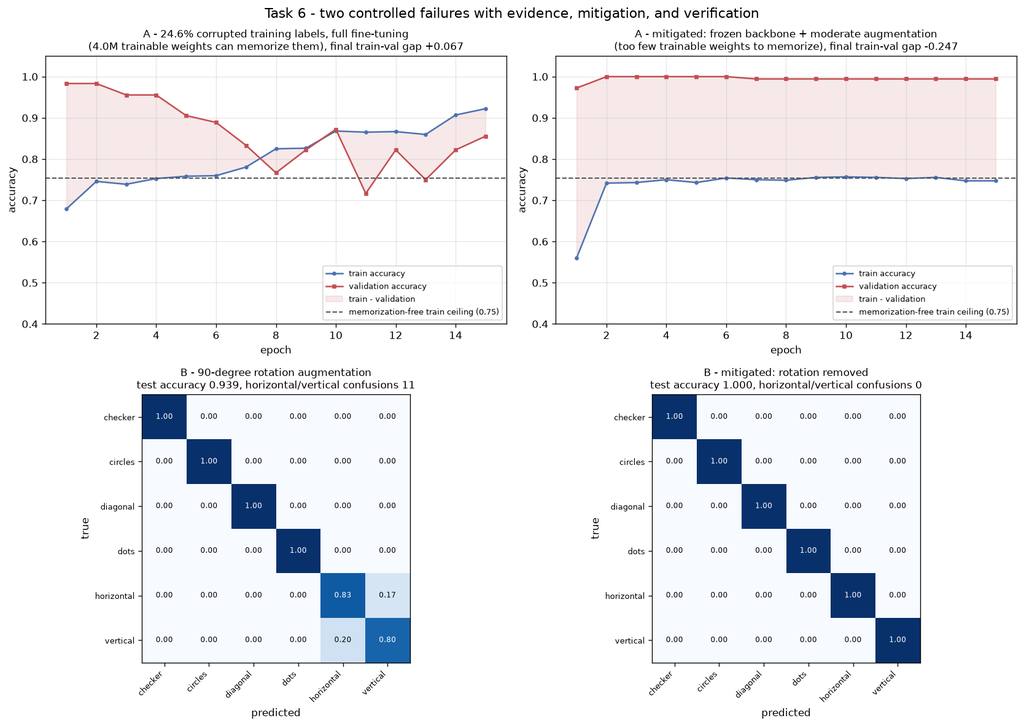

```python
# =============================================================================================
# Failure A - LABEL NOISE driving OVERFITTING (memorization).
# 30% of the TRAINING labels are randomly reassigned while validation and test stay clean. The
# full backbone is fine-tuned, so the network has more than enough capacity to memorize the
# corrupted targets instead of learning the pattern, and validation accuracy falls.
# Mitigation: remove that capacity (freeze the backbone, head only) and add moderate
# augmentation, so the model can no longer fit the noise.
# =============================================================================================
LABEL_NOISE, FAILURE_EPOCHS = 0.30, 15


def noisy_label_loaders(fraction, augmentation, seed):
    """Loaders whose TRAIN labels are randomly corrupted; validation and test labels stay clean."""
    base = sc.build_dataloaders(a3_tools.dataset_path(), BATCH_SIZE, augmentation, seed, NUM_WORKERS)
    clean = base["train"].dataset.labels.copy()
    generator = np.random.default_rng(seed)
    chosen = generator.choice(len(clean), int(round(fraction * len(clean))), replace=False)
    noisy = clean.copy()
    noisy[chosen] = generator.integers(0, NUM_CLASSES, len(chosen))
    dataset = sc.ArrayImageDataset(archive["train_images"], noisy,
                                   base["train"].dataset.transform, CLASS_NAMES)
    base["train"] = DataLoader(dataset, batch_size=BATCH_SIZE, shuffle=True, num_workers=NUM_WORKERS,
                               generator=torch.Generator().manual_seed(seed))
    return base, float((noisy != clean).mean())


noisy_loaders, actual_noise = noisy_label_loaders(LABEL_NOISE, "none", SEED)
print(f"training labels actually corrupted: {actual_noise:.1%} of 720 "
      f"(validation and test labels untouched)\n")
FAILURE_A = run_training("failA_label_noise_overfit", architecture=BEST_ARCHITECTURE, mode="finetune",
                         augmentation="none", optimizer_name="adam", lr=1e-3, epochs=FAILURE_EPOCHS,
                         seed=SEED, loaders=noisy_loaders, num_classes=NUM_CLASSES,
                         class_names=CLASS_NAMES)
mitigated_loaders, _ = noisy_label_loaders(LABEL_NOISE, "moderate", SEED)
FAILURE_A_FIX = run_training("failA_mitigated", architecture=BEST_ARCHITECTURE, mode="frozen",
                             augmentation="moderate", optimizer_name="adam", lr=1e-3,
                             epochs=FAILURE_EPOCHS, seed=SEED, loaders=mitigated_loaders,
                             num_classes=NUM_CLASSES, class_names=CLASS_NAMES)
_, failure_a_metrics = test_report(FAILURE_A)
_, failure_a_fix_metrics = test_report(FAILURE_A_FIX)
# A model that learns only the true pattern predicts the true class, so it gets every unchanged
# label right and every changed label wrong: its training accuracy tops out at 1 - (changed
# fraction). Anything above it is memorization of the noise.
NOISE_CEILING = 1 - actual_noise
print(f"\nFailure A - {actual_noise:.1%} corrupted training labels (final-epoch values; "
      f"clean validation/test)")
print(f"  memorization-free training-accuracy ceiling ~ {NOISE_CEILING:.4f}")
print(f"  before: train {FAILURE_A['final_train_accuracy']:.4f} "
      f"({FAILURE_A['final_train_accuracy'] - NOISE_CEILING:+.4f} vs ceiling) / "
      f"val {FAILURE_A['final_val_accuracy']:.4f} -> gap {FAILURE_A['final_gap']:+.4f}"
      f" | clean test {failure_a_metrics['accuracy']:.4f} | trainable "
      f"{FAILURE_A['parameter_counts']['trainable']:,}")
print(f"  after : train {FAILURE_A_FIX['final_train_accuracy']:.4f} "
      f"({FAILURE_A_FIX['final_train_accuracy'] - NOISE_CEILING:+.4f} vs ceiling) / "
      f"val {FAILURE_A_FIX['final_val_accuracy']:.4f} -> gap {FAILURE_A_FIX['final_gap']:+.4f}"
      f" | clean test {failure_a_fix_metrics['accuracy']:.4f} | trainable "
      f"{FAILURE_A_FIX['parameter_counts']['trainable']:,}")
print(f"  verified change: validation accuracy "
      f"{FAILURE_A_FIX['final_val_accuracy'] - FAILURE_A['final_val_accuracy']:+.4f}, "
      f"clean test accuracy {failure_a_fix_metrics['accuracy'] - failure_a_metrics['accuracy']:+.4f}, "
      f"train-validation gap {FAILURE_A_FIX['final_gap'] - FAILURE_A['final_gap']:+.4f}")

# =============================================================================================
# Failure B - AUGMENTATION MISMATCH: 90-degree rotations rewrite the orientation classes, so
# `horizontal` and `vertical` become the same training distribution.
# Mitigation: drop the rotation and keep only the label-preserving flips/jitter.
# =============================================================================================
ROTATION_TRANSFORM = transforms.Compose([
    transforms.Resize((sc.IMAGE_SIZE, sc.IMAGE_SIZE)),
    transforms.RandomChoice([transforms.RandomRotation((angle, angle)) for angle in (0, 90, 180, 270)]),
    transforms.ToTensor(), transforms.Normalize(sc.IMAGENET_MEAN, sc.IMAGENET_STD)])


def rotated_loaders(seed):
    """Loaders whose TRAIN transform adds label-destroying 90-degree rotations."""
    base = sc.build_dataloaders(a3_tools.dataset_path(), BATCH_SIZE, "none", seed, NUM_WORKERS)
    dataset = sc.ArrayImageDataset(archive["train_images"], archive["train_labels"],
                                   ROTATION_TRANSFORM, CLASS_NAMES)
    base["train"] = DataLoader(dataset, batch_size=BATCH_SIZE, shuffle=True, num_workers=NUM_WORKERS,
                               generator=torch.Generator().manual_seed(seed))
    return base


FAILURE_B = run_training("failB_rotation_mismatch", architecture=BEST_ARCHITECTURE, mode="finetune",
                         augmentation="rot90", optimizer_name="adam", epochs=8, seed=SEED,
                         loaders=rotated_loaders(SEED), num_classes=NUM_CLASSES, class_names=CLASS_NAMES)
FAILURE_B_FIX = run_training("failB_mitigated", architecture=BEST_ARCHITECTURE, mode="finetune",
                             augmentation="moderate", optimizer_name="adam", epochs=8, seed=SEED,
                             num_classes=NUM_CLASSES, class_names=CLASS_NAMES)
_, failure_b_metrics = test_report(FAILURE_B)
_, failure_b_fix_metrics = test_report(FAILURE_B_FIX)
ORIENTED = [CLASS_NAMES.index("horizontal"), CLASS_NAMES.index("vertical")]
confusion_before = failure_b_metrics["confusion_matrix"]
confusion_after = failure_b_fix_metrics["confusion_matrix"]
swap = lambda matrix: int(matrix[ORIENTED[0], ORIENTED[1]] + matrix[ORIENTED[1], ORIENTED[0]])
oriented_accuracy = lambda metrics: float(np.mean([metrics["per_class_accuracy"][i] for i in ORIENTED]))
print(f"\nFailure B (90-degree rotation augmentation destroys orientation labels)")
print(f"  before: test accuracy {failure_b_metrics['accuracy']:.4f} | horizontal/vertical accuracy "
      f"{oriented_accuracy(failure_b_metrics):.4f} | mutual confusions {swap(confusion_before)}")
print(f"  after : test accuracy {failure_b_fix_metrics['accuracy']:.4f} | horizontal/vertical accuracy "
      f"{oriented_accuracy(failure_b_fix_metrics):.4f} | mutual confusions {swap(confusion_after)}")
print(f"  verified change: accuracy {failure_b_fix_metrics['accuracy'] - failure_b_metrics['accuracy']:+.4f}, "
      f"mutual confusions {swap(confusion_after) - swap(confusion_before):+d}")

for experiment_label, before, after, before_metrics, after_metrics in (
        ("failure_A_label_noise_overfitting", FAILURE_A, FAILURE_A_FIX, failure_a_metrics, failure_a_fix_metrics),
        ("failure_B_augmentation_mismatch", FAILURE_B, FAILURE_B_FIX, failure_b_metrics, failure_b_fix_metrics)):
    for stage, run, metrics in (("before_mitigation", before, before_metrics),
                                ("after_mitigation", after, after_metrics)):
        condition = f"{experiment_label}/{stage}"
        record("task6", "failure analysis", condition, "final_train_accuracy", run["final_train_accuracy"], "fraction")
        record("task6", "failure analysis", condition, "final_val_accuracy", run["final_val_accuracy"], "fraction")
        record("task6", "failure analysis", condition, "best_val_accuracy", run["best_val_accuracy"], "fraction")
        record("task6", "failure analysis", condition, "final_train_val_gap", run["final_gap"], "fraction")
        record("task6", "failure analysis", condition, "test_accuracy", metrics["accuracy"], "fraction")
        record("task6", "failure analysis", condition, "test_macro_f1", metrics["macro_f1"], "fraction")
record("task6", "failure analysis", "failure_A_label_noise_overfitting", "corrupted_label_fraction",
       actual_noise, "fraction")
record("task6", "failure analysis", "failure_A_label_noise_overfitting",
       "memorization_free_train_ceiling", NOISE_CEILING, "fraction")
record("task6", "failure analysis", "failure_A_label_noise_overfitting", "gap_reduction",
       FAILURE_A["final_gap"] - FAILURE_A_FIX["final_gap"], "fraction")
record("task6", "failure analysis", "failure_A_label_noise_overfitting", "clean_test_accuracy_gain",
       failure_a_fix_metrics["accuracy"] - failure_a_metrics["accuracy"], "fraction")
record("task6", "failure analysis", "failure_B_augmentation_mismatch", "oriented_class_accuracy_gain",
       oriented_accuracy(failure_b_fix_metrics) - oriented_accuracy(failure_b_metrics), "fraction")
record("task6", "failure analysis", "failure_B_augmentation_mismatch", "horizontal_vertical_confusions_before",
       swap(confusion_before), "count")
record("task6", "failure analysis", "failure_B_augmentation_mismatch", "horizontal_vertical_confusions_after",
       swap(confusion_after), "count")

# --- failure_analysis.png ----------------------------------------------------------------------
figure, axes = plt.subplots(2, 2, figsize=(14, 10), dpi=120)
for axis, run, title in ((axes[0, 0], FAILURE_A,
                          f"A - {actual_noise:.1%} corrupted training labels, full fine-tuning\n"
                          f"(4.0M trainable weights can memorize them)"),
                         (axes[0, 1], FAILURE_A_FIX,
                          "A - mitigated: frozen backbone + moderate augmentation\n"
                          "(too few trainable weights to memorize)")):
    history = run["history"]
    axis.plot(history["epoch"], history["train_accuracy"], "-o", ms=3, color="#4c72b0", label="train accuracy")
    axis.plot(history["epoch"], history["val_accuracy"], "-s", ms=3, color="#c44e52", label="validation accuracy")
    axis.fill_between(history["epoch"], history["val_accuracy"], history["train_accuracy"],
                      color="#c44e52", alpha=0.12, label="train - validation")
    axis.axhline(NOISE_CEILING, ls="--", lw=1.2, color="#555555",
                 label=f"memorization-free train ceiling ({NOISE_CEILING:.2f})")
    axis.set_title(f"{title}, final train-val gap {run['final_gap']:+.3f}", fontsize=10)
    axis.set_xlabel("epoch"); axis.set_ylabel("accuracy"); axis.set_ylim(0.4, 1.05)
    axis.grid(alpha=0.3); axis.legend(fontsize=8, loc="lower right")
draw_confusion(axes[1, 0], confusion_before, CLASS_NAMES, normalize=True,
               title=f"B - 90-degree rotation augmentation\ntest accuracy {failure_b_metrics['accuracy']:.3f}, "
                     f"horizontal/vertical confusions {swap(confusion_before)}")
draw_confusion(axes[1, 1], confusion_after, CLASS_NAMES, normalize=True,
               title=f"B - mitigated: rotation removed\ntest accuracy {failure_b_fix_metrics['accuracy']:.3f}, "
                     f"horizontal/vertical confusions {swap(confusion_after)}")
figure.suptitle("Task 6 - two controlled failures with evidence, mitigation, and verification", fontsize=13)
figure.tight_layout()
figure.savefig(PATHS["figures"] / "failure_analysis.png", bbox_inches="tight")
print("\nsaved", (PATHS["figures"] / "failure_analysis.png").name)
write_metrics().tail(3)
plt.close(figure)  # displayed once, as the cell result
figure
```

**Failure analysis:** I will put this bluntly: bad labels and incorrect augmentation can greatly cause training data to corrupt. From my results, when training labels became corrupted (24.6%), the fully fine-tuned model began memorizing those incorrect labels which hurt the validation performance (85.56%). Once mitigation was implemented, the tests were clean and the validation accuracy improved to 99.44%, and a clean test accuracy of 100%. The augmentation error was much more simple. The 90-degree rotation caused a problem because rotating horizontal patterns to vertical patterns, while keeping the original labels, caused confusion between the two classes which reduced its test accuracy. When the label-preserving augmentation is used, the confusion is removed and is restored back to 100% accuracy.

## 8. Extension

### Task 7 — Extension (10 points)

Choose Grad-CAM, saliency, MixUp, CutMix, a cosine scheduler, label smoothing, knowledge distillation, or an approved recognition enhancement. Submit one artifact under `outputs/extension/`, one controlled baseline comparison, and a concise evidence-based conclusion. Use no additional packages or externally pretrained pipeline.

```
[ext_baseline_ce] efficientnet_b0 | frozen | aug=none | sgd lr=0.01 | best val acc 1.0000 @ epoch 2 | final train acc 0.9986 | gap -0.0014 | trainable 7,686 | 39.3s
```

```
[ext_label_smoothing_0.1] efficientnet_b0 | frozen | aug=none | sgd lr=0.01 | best val acc 1.0000 @ epoch 2 | final train acc 1.0000 | gap +0.0000 | trainable 7,686 | 40.9s
```

```
          condition  label_smoothing  best_val_accuracy  test_accuracy  test_macro_f1  test_loss  mean_confidence  mean_confidence_correct  mean_confidence_wrong  overconfidence_gap
        baseline_ce              0.0                1.0            1.0            1.0     0.0322           0.9702                   0.9702                    NaN             -0.0298
label_smoothing_0.1              0.1                1.0            1.0            1.0     0.0724           0.9339                   0.9339                    NaN             -0.0661

test accuracy 1.0000 -> 1.0000 (+0.0000) | overconfidence gap -0.0298 -> -0.0661 (-0.0363)
```

```
saved outputs/extension/label_smoothing_comparison.png

cumulative metrics: 281 records -> experiment_metrics.csv
```

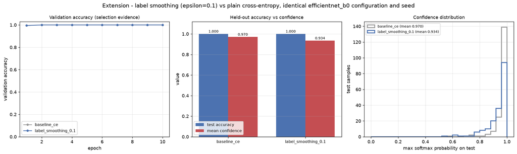

```python
# ============================================================================================
# Extension: LABEL SMOOTHING (epsilon = 0.1) against an otherwise identical baseline.
# Question: does label smoothing change held-out accuracy, or only confidence calibration?
# Controlled: identical architecture, mode, augmentation, optimizer, lr, loaders, seed, epochs;
# the training loss function is the only difference, and both are evaluated with plain
# cross-entropy on the same splits.
# ============================================================================================
SMOOTHING = 0.1
EXTENSION_RUNS = {}
for label, epsilon in (("baseline_ce", 0.0), (f"label_smoothing_{SMOOTHING:g}", SMOOTHING)):
    EXTENSION_RUNS[label] = run_training(f"ext_{label}", epochs=EPOCHS, seed=SEED,
                                         label_smoothing=epsilon, **SELECTED_CONFIG)

extension_rows = []
for label, run in EXTENSION_RUNS.items():
    evaluation, metrics = test_report(run)
    confidence = evaluation["probabilities"].max(axis=1)
    correct = evaluation["predictions"] == evaluation["labels"]
    row = {"condition": label, "label_smoothing": run["label_smoothing"],
           "best_val_accuracy": run["best_val_accuracy"], "test_accuracy": metrics["accuracy"],
           "test_macro_f1": metrics["macro_f1"], "test_loss": evaluation["loss"],
           "mean_confidence": float(confidence.mean()),
           "mean_confidence_correct": float(confidence[correct].mean()) if correct.any() else float("nan"),
           "mean_confidence_wrong": float(confidence[~correct].mean()) if (~correct).any() else float("nan"),
           "overconfidence_gap": float(confidence.mean() - metrics["accuracy"])}
    extension_rows.append(row)
    EXTENSION_RUNS[label] = {**run, "confidence": confidence, "correct": correct,
                             "metrics": metrics, "evaluation": evaluation}
    for metric in ("best_val_accuracy", "test_accuracy", "test_macro_f1", "mean_confidence",
                   "overconfidence_gap"):
        record("task7", "extension: label smoothing", label, metric, row[metric],
               "cross-entropy" if metric == "test_loss" else "fraction")

extension_table = pd.DataFrame(extension_rows)
baseline, smoothed = extension_rows[0], extension_rows[1]
record("task7", "extension: label smoothing", "smoothed minus baseline", "test_accuracy_delta",
       smoothed["test_accuracy"] - baseline["test_accuracy"], "fraction")
record("task7", "extension: label smoothing", "smoothed minus baseline", "overconfidence_gap_delta",
       smoothed["overconfidence_gap"] - baseline["overconfidence_gap"], "fraction")
print(extension_table.round(4).to_string(index=False))
print(f"\ntest accuracy {baseline['test_accuracy']:.4f} -> {smoothed['test_accuracy']:.4f} "
      f"({smoothed['test_accuracy'] - baseline['test_accuracy']:+.4f}) | "
      f"overconfidence gap {baseline['overconfidence_gap']:+.4f} -> {smoothed['overconfidence_gap']:+.4f} "
      f"({smoothed['overconfidence_gap'] - baseline['overconfidence_gap']:+.4f})")

# --- outputs/extension/label_smoothing_comparison.png ------------------------------------------
figure, axes = plt.subplots(1, 3, figsize=(16, 4.8), dpi=130)
palette = {"baseline_ce": "#999999", f"label_smoothing_{SMOOTHING:g}": "#4c72b0"}
for label, run in EXTENSION_RUNS.items():
    history = run["history"]
    axes[0].plot(history["epoch"], history["val_accuracy"], "-o", ms=4, color=palette[label], label=label)
axes[0].set_xlabel("epoch"); axes[0].set_ylabel("validation accuracy"); axes[0].set_ylim(0, 1.03)
axes[0].grid(alpha=0.3); axes[0].legend(fontsize=9); axes[0].set_title("Validation accuracy (selection evidence)",
                                                                        fontsize=10)
positions = np.arange(len(extension_rows))
width = 0.38
axes[1].bar(positions - width / 2, extension_table["test_accuracy"], width, color="#4c72b0", label="test accuracy")
axes[1].bar(positions + width / 2, extension_table["mean_confidence"], width, color="#c44e52",
            label="mean confidence")
for position, row in enumerate(extension_rows):
    axes[1].annotate(f"{row['test_accuracy']:.3f}", (position - width / 2, row["test_accuracy"]),
                     textcoords="offset points", xytext=(0, 3), ha="center", fontsize=8)
    axes[1].annotate(f"{row['mean_confidence']:.3f}", (position + width / 2, row["mean_confidence"]),
                     textcoords="offset points", xytext=(0, 3), ha="center", fontsize=8)
axes[1].set_xticks(positions, extension_table["condition"], fontsize=9)
axes[1].set_ylim(0, 1.12); axes[1].set_ylabel("value"); axes[1].grid(axis="y", alpha=0.3)
axes[1].legend(fontsize=9); axes[1].set_title("Held-out accuracy vs confidence", fontsize=10)
for label, run in EXTENSION_RUNS.items():
    axes[2].hist(run["confidence"], bins=np.linspace(0, 1, 26), histtype="step", lw=2,
                 color=palette[label], label=f"{label} (mean {run['confidence'].mean():.3f})")
axes[2].set_xlabel("max softmax probability on test"); axes[2].set_ylabel("test samples")
axes[2].grid(alpha=0.3); axes[2].legend(fontsize=8); axes[2].set_title("Confidence distribution", fontsize=10)
figure.suptitle(f"Extension - label smoothing (epsilon={SMOOTHING}) vs plain cross-entropy, "
                f"identical {SELECTED_CONFIG['architecture']} configuration and seed", fontsize=12)
figure.tight_layout()
figure.savefig(PATHS["extension"] / "label_smoothing_comparison.png", bbox_inches="tight")
print("\nsaved outputs/extension/" + (PATHS["extension"] / "label_smoothing_comparison.png").name)
write_metrics()
print("\ncumulative metrics:", len(METRIC_ROWS), "records ->", METRICS_PATH.name)
plt.close(figure)  # displayed once, as the cell result
figure
```

**Extension question and conclusion:** The question I asked myself was: “does label smoothing improve accuracy?” First, there is one important detail: both models got 100% test accuracy. So, this does not prove that label smoothing improves test accuracies. Rather, it changes the confidence; it dropped from 97.02% to 93.39%. Therefore, label smoothing more-so changes the confidence calibration rather than benefiting overall classification performance.

## 9. Reflection and Reproducibility

Reproducibility, organization, and submission compliance are worth **5 points**: split discipline, seeds, model-selection record, correct execution, artifacts, schemas, checkpoint, disclosure, and packaging. In a few sentences, identify one reproducibility decision, one metric limitation, and one practice you will carry forward.

## 10. Submission Validation

Restart the kernel, run all cells, and export current HTML as `A3.html`. Then run:

```
python /path/to/common-setup/scripts/validate_submission.py --assignment A3
python /path/to/common-setup/scripts/package_submission.py --assignment A3
```

Submit `LastName_FirstName_A3.zip`. Do not submit PDF, dataset or pretrained-weight copies, caches, environments, experiment-tracking directories, or nested ZIP files.

### Canvas submission checklist

- The ZIP contains exactly one top-level folder named `LastName_FirstName_A3`.
- Section 0 identity fields (first name, last name, ABC123) are complete.
- `A3.ipynb` was restarted, run top to bottom, and saved without errors, and `A3.html` was exported after that final run.
- `src/` contains the required source files: `a3_tools.py` and `student_code.py`.
- `outputs/` contains only the required figures, tables, the `trained_model.pt` checkpoint (state dictionary only, no optimizer state, ≤25 MB), and one extension artifact — no extra files.
- `python scripts/validate_submission.py --assignment A3` reports zero errors; review any warnings.
- No datasets, pretrained-weight copies, environments, caches, extra checkpoints, hidden files, or temporary files are included.
- External resources and meaningful generative-AI use are disclosed in Section 0.
- A PDF export is not required and is not included.

```python
for category in ("figures", "tables", "models", "extension"):
    print(category, sorted(p.name for p in PATHS[category].glob("*") if p.is_file()))
metrics_frame = pd.read_csv(METRICS_PATH)
print("\nexperiment_metrics.csv", metrics_frame.shape, "| columns", list(metrics_frame.columns))
print(metrics_frame.groupby("experiment")["metric"].count().rename("records").to_string())
print("\nmodel_metadata.json")
print(json.dumps(json.loads((PATHS["tables"] / "model_metadata.json").read_text()), indent=2))
```

```
figures ['.gitkeep', 'augmentation_examples.png', 'confusion_matrix.png', 'embedding_visualization.png', 'eurosat_transfer_results.png', 'failure_analysis.png', 'robustness_results.png', 'skin_cancer_class_balance.png', 'training_curves.png']
tables ['.gitkeep', 'experiment_metrics.csv', 'model_metadata.json', 'predictions.csv']
models ['.gitkeep', 'trained_model.pt']
extension ['.gitkeep', 'label_smoothing_comparison.png']

experiment_metrics.csv (281, 6) | columns ['experiment', 'method', 'condition', 'metric', 'value', 'units']
experiment
1        22
2        20
3        30
4        22
5        13
6        27
7        21
8        36
9        47
task6    31
task7    12

model_metadata.json
{
  "architecture": "efficientnet_b0",
  "num_classes": 6,
  "class_names": [
    "checker",
    "circles",
    "diagonal",
    "dots",
    "horizontal",
    "vertical"
  ],
  "checkpoint": "outputs/models/trained_model.pt",
  "parameter_counts": {
    "total": 4015234,
    "trainable": 7686
  },
  "seed": 5243,
  "selected_by": "factor-wise winners of Experiments 1-4, each chosen on validation accuracy with validation loss as tie-break; the reported epoch is the best validation epoch. The test split was not consulted for any selection decision.",
  "training": {
    "mode": "frozen",
    "augmentation": "none",
    "optimizer": "sgd",
    "learning_rate": 0.01,
    "epochs": 10,
    "selected_epoch": 2,
    "batch_size": 32,
    "image_size": 224
  },
  "validation_accuracy": 1.0,
  "test_accuracy": 1.0
}
```